# Elsevier 2022 SDG mapping

# General to all SDGs

## Introduction

The United Nations Sustainable Development Goals (SDGs) challenge the global community to build a world where no one is left behind.

Since 2018, Elsevier has generated SDG search queries to help researchers and institutions track and demonstrate progress toward the SDG targets. In the past 3 years, these queries, along with the university’s own data and evidence supporting progress and contributions to the particular SDG outside of research-based metrics, are used for the THE Impact Rankings.

## Method

For 2022, this SDG uses the exact same search query and ML algorithm as the Elsevier 2021 SDG mapping. [Full details of the 2021 methodology are available on Digital Commons Data.](https://elsevier.digitalcommonsdata.com/datasets/9sxdykm8s4/4)

# [SDG 15 - Protect, restore and promote sustainable use of terrestrial ecosystems, sustainably manage forests, combat desertification, and halt and reverse land degradation and halt biodiversity loss](https://sdgs.un.org/goals/goal15)

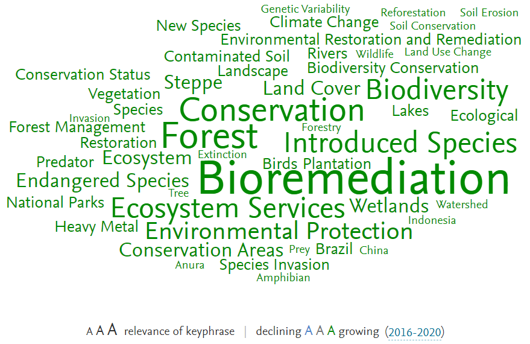

Explore this wordcloud plus the most active contributors on the [SciVal SDG site](https://scival.com/sdg)

## Query

Below is the full search query used for this SDG. We’ve broken it down by each query component. Use the + and – to concatenate the different bracket levels.

(

(

TITLE

(

"CITES"

)

OR AUTHKEY

(

"CITES"

)

OR TITLE

(

"elephant ivory"

)

OR AUTHKEY

(

"elephant ivory"

)

OR TITLE

(

"poacher"

)

OR AUTHKEY

(

"poacher"

)

OR TITLE

(

"rhino horn"

)

OR AUTHKEY

(

"rhino horn"

)

OR

(

TITLE-ABS

(

"unreported fishing"

)

AND NOT

(

(TITLE-ABS("marine") OR TITLE-ABS("marines") OR TITLE-ABS("ocean") OR TITLE-ABS("oceans") OR TITLE-ABS("sea") OR TITLE-ABS("island") OR TITLE-ABS("islands") OR TITLE-ABS("Coastal") OR TITLE-ABS("coast"))

)

)

OR

(

AUTHKEY

(

"unreported fishing"

)

AND NOT

(

(AUTHKEY("marine") OR AUTHKEY("marines") OR AUTHKEY("ocean") OR AUTHKEY("oceans") OR AUTHKEY("sea") OR AUTHKEY("island") OR AUTHKEY("islands") OR AUTHKEY("Coastal") OR AUTHKEY("coast"))

)

)

OR TITLE-ABS

(

"illegal wildlife"

)

OR AUTHKEY

(

"illegal wildlife"

)

OR TITLE-ABS

(

"illegal killing"

)

OR AUTHKEY

(

"illegal killing"

)

OR TITLE-ABS

(

"wildlife crimes"

)

OR AUTHKEY

(

"wildlife crimes"

)

OR

(

TITLE-ABS

(

"CITES"

)

AND TITLE-ABS

(

"appendix ii"

)

)

OR

(

AUTHKEY

(

"CITES"

)

AND AUTHKEY

(

"appendix ii"

)

)

OR

(

TITLE-ABS

(

"iuu fishing"

)

AND NOT

(

(TITLE-ABS("marine") OR TITLE-ABS("marines") OR TITLE-ABS("ocean") OR TITLE-ABS("oceans") OR TITLE-ABS("sea") OR TITLE-ABS("island") OR TITLE-ABS("islands") OR TITLE-ABS("Coastal") OR TITLE-ABS("coast"))

)

)

OR

(

AUTHKEY

(

"iuu fishing"

)

AND NOT

(

(AUTHKEY("marine") OR AUTHKEY("marines") OR AUTHKEY("ocean") OR AUTHKEY("oceans") OR AUTHKEY("sea") OR AUTHKEY("island") OR AUTHKEY("islands") OR AUTHKEY("Coastal") OR AUTHKEY("coast"))

)

)

OR TITLE-ABS

(

"Wildlife Trading"

)

OR AUTHKEY

(

"Wildlife Trading"

)

OR TITLE-ABS

(

"illegal hunting"

)

OR AUTHKEY

(

"illegal hunting"

)

OR

(

TITLE-ABS

(

"illegal trade"

)

AND TITLE-ABS

(

"endangered species"

)

)

OR

(

AUTHKEY

(

"illegal trade"

)

AND AUTHKEY

(

"endangered species"

)

)

OR

(

TITLE-ABS

(

" pet trade"

)

AND TITLE-ABS

(

"illegal"

)

)

OR

(

AUTHKEY

(

" pet trade"

)

AND AUTHKEY

(

"illegal"

)

)

OR TITLE-ABS

(

"ivory trade"

)

OR AUTHKEY

(

"ivory trade"

)

OR

(

TITLE-ABS

(

"wild fauna"

)

AND TITLE-ABS

(

"illegal"

)

)

OR

(

AUTHKEY

(

"wild fauna"

)

AND AUTHKEY

(

"illegal"

)

)

OR TITLE-ABS

(

"unregulated hunting"

)

OR AUTHKEY

(

"unregulated hunting"

)

OR TITLE-ABS

(

"CITES appendix"

)

OR AUTHKEY

(

"CITES appendix"

)

OR

(

TITLE-ABS

(

"wild meat"

)

AND TITLE-ABS

(

"hunted"

)

)

OR

(

AUTHKEY

(

"wild meat"

)

AND AUTHKEY

(

"hunted"

)

)

OR

(

TITLE-ABS

(

"wild fauna"

)

AND TITLE-ABS

(

"trade"

)

)

OR

(

AUTHKEY

(

"wild fauna"

)

AND AUTHKEY

(

"trade"

)

)

OR

(

TITLE-ABS

(

"CITES"

)

AND TITLE-ABS

(

"appendix i"

)

)

OR

(

AUTHKEY

(

"CITES"

)

AND AUTHKEY

(

"appendix i"

)

)

OR

(

(

TITLE-ABS("fishing") AND TITLE-ABS("endangered species")

)

AND NOT

(

(TITLE-ABS("marine") OR TITLE-ABS("marines") OR TITLE-ABS("ocean") OR TITLE-ABS("oceans") OR TITLE-ABS("sea"))

)

)

OR

(

(

AUTHKEY("fishing") AND AUTHKEY("endangered species")

)

AND NOT

(

(AUTHKEY("marine") OR AUTHKEY("marines") OR AUTHKEY("ocean") OR AUTHKEY("oceans") OR AUTHKEY("sea"))

)

)

OR

(

TITLE-ABS

(

"wild meat"

)

AND TITLE-ABS

(

"hunting"

)

)

OR

(

AUTHKEY

(

"wild meat"

)

AND AUTHKEY

(

"hunting"

)

)

OR

(

TITLE-ABS

(

"bushmeat"

)

AND TITLE-ABS

(

"hunting"

)

)

OR

(

AUTHKEY

(

"bushmeat"

)

AND AUTHKEY

(

"hunting"

)

)

OR

(

TITLE-ABS

(

"unregulated fishing"

)

AND NOT

(

(TITLE-ABS("marine") OR TITLE-ABS("marines") OR TITLE-ABS("ocean") OR TITLE-ABS("oceans") OR TITLE-ABS("sea") OR TITLE-ABS("island") OR TITLE-ABS("islands") OR TITLE-ABS("Coastal") OR TITLE-ABS("coast"))

)

)

OR

(

AUTHKEY

(

"unregulated fishing"

)

AND NOT

(

(AUTHKEY("marine") OR AUTHKEY("marines") OR AUTHKEY("ocean") OR AUTHKEY("oceans") OR AUTHKEY("sea") OR AUTHKEY("island") OR AUTHKEY("islands") OR AUTHKEY("Coastal") OR AUTHKEY("coast"))

)

)

OR TITLE-ABS

(

"poached"

)

OR AUTHKEY

(

"poached"

)

OR TITLE-ABS

(

"international trade in endangered species"

)

OR AUTHKEY

(

"international trade in endangered species"

)

OR

(

TITLE-ABS

(

"environmental crime"

)

AND TITLE-ABS

(

"hunting"

)

)

OR

(

AUTHKEY

(

"environmental crime"

)

AND AUTHKEY

(

"hunting"

)

)

OR

(

(

TITLE-ABS("hunting") AND TITLE-ABS("endangered species")

)

AND NOT

(

(TITLE-ABS("marine") OR TITLE-ABS("marines") OR TITLE-ABS("ocean") OR TITLE-ABS("oceans") OR TITLE-ABS("sea"))

)

)

OR

(

(

AUTHKEY("hunting") AND AUTHKEY("endangered species")

)

AND NOT

(

(AUTHKEY("marine") OR AUTHKEY("marines") OR AUTHKEY("ocean") OR AUTHKEY("oceans") OR AUTHKEY("sea"))

)

)

OR

(

TITLE-ABS

(

"CITES"

)

AND TITLE-ABS

(

"appendix iii"

)

)

OR

(

AUTHKEY

(

"CITES"

)

AND AUTHKEY

(

"appendix iii"

)

)

OR

(

TITLE-ABS

(

"bushmeat"

)

AND TITLE-ABS

(

"illegal"

)

)

OR

(

AUTHKEY

(

"bushmeat"

)

AND AUTHKEY

(

"illegal"

)

)

OR TITLE-ABS

(

"wildlife forensics"

)

OR AUTHKEY

(

"wildlife forensics"

)

OR TITLE-ABS

(

"trophy hunting"

)

OR AUTHKEY

(

"trophy hunting"

)

OR TITLE-ABS

(

"hunting ban"

)

OR AUTHKEY

(

"hunting ban"

)

OR TITLE-ABS

(

"illegal bushmeat"

)

OR AUTHKEY

(

"illegal bushmeat"

)

OR TITLE-ABS

(

"illegal harvest"

)

OR AUTHKEY

(

"illegal harvest"

)

OR TITLE-ABS

(

"Trade of Endangered Species"

)

OR AUTHKEY

(

"Trade of Endangered Species"

)

OR

(

TITLE-ABS

(

"illegal fishing"

)

AND NOT

(

(TITLE-ABS("marine") OR TITLE-ABS("marines") OR TITLE-ABS("ocean") OR TITLE-ABS("oceans") OR TITLE-ABS("sea") OR TITLE-ABS("island") OR TITLE-ABS("islands"))

)

)

OR

(

AUTHKEY

(

"illegal fishing"

)

AND NOT

(

(AUTHKEY("marine") OR AUTHKEY("marines") OR AUTHKEY("ocean") OR AUTHKEY("oceans") OR AUTHKEY("sea") OR AUTHKEY("island") OR AUTHKEY("islands"))

)

)

OR TITLE-ABS

(

"Wildlife Trade"

)

OR AUTHKEY

(

"Wildlife Trade"

)

OR TITLE-ABS

(

"wildlife forensic"

)

OR AUTHKEY

(

"wildlife forensic"

)

OR TITLE-ABS

(

"illegal wildlife trade"

)

OR AUTHKEY

(

"illegal wildlife trade"

)

OR TITLE-ABS

(

"antipoaching"

)

OR AUTHKEY

(

"antipoaching"

)

OR TITLE-ABS

(

"illegal trade in wildlife"

)

OR AUTHKEY

(

"illegal trade in wildlife"

)

OR TITLE-ABS

(

"illegal harvesting"

)

OR AUTHKEY

(

"illegal harvesting"

)

OR TITLE-ABS

(

"wildlife markets"

)

OR AUTHKEY

(

"wildlife markets"

)

OR

(

TITLE-ABS

(

"hunting"

)

AND

(

TITLE-ABS("red list") OR TITLE-ABS("IUCN")

)

)

OR

(

AUTHKEY

(

"hunting"

)

AND

(

AUTHKEY("red list") OR AUTHKEY("IUCN")

)

)

OR TITLE-ABS

(

"convention on international trade in endangered species"

)

OR AUTHKEY

(

"convention on international trade in endangered species"

)

OR TITLE-ABS

(

"green criminology"

)

OR AUTHKEY

(

"green criminology"

)

OR

(

TITLE-ABS

(

"hunted"

)

AND

(

TITLE-ABS("red list") OR TITLE-ABS("IUCN")

)

)

OR

(

AUTHKEY

(

"hunted"

)

AND

(

AUTHKEY("red list") OR AUTHKEY("IUCN")

)

)

OR TITLE-ABS

(

"poachers"

)

OR AUTHKEY

(

"poachers"

)

OR

(

TITLE-ABS

(

"illegal"

)

AND

(

TITLE-ABS("wildlife trade") OR TITLE-ABS("plant harvesting")

)

)

OR

(

AUTHKEY

(

"illegal"

)

AND

(

AUTHKEY("wildlife trade") OR AUTHKEY("plant harvesting")

)

)

OR TITLE-ABS

(

"wildlife trafficking"

)

OR AUTHKEY

(

"wildlife trafficking"

)

OR TITLE-ABS

(

"poaching"

)

OR AUTHKEY

(

"poaching"

)

OR TITLE-ABS

(

"animal trafficking"

)

OR AUTHKEY

(

"animal trafficking"

)

OR TITLE-ABS

(

"wildlife smuggling"

)

OR AUTHKEY

(

"wildlife smuggling"

)

OR TITLE-ABS

(

"wildlife crime"

)

OR AUTHKEY

(

"wildlife crime"

)

)

)

OR

(

(

TITLE-ABS

(

"afforestations"

)

OR AUTHKEY

(

"afforestations"

)

OR TITLE-ABS

(

"new forest policy"

)

OR AUTHKEY

(

"new forest policy"

)

OR TITLE-ABS

(

"creation of forests"

)

OR AUTHKEY

(

"creation of forests"

)

OR TITLE-ABS

(

"artificial afforestation"

)

OR AUTHKEY

(

"artificial afforestation"

)

OR TITLE-ABS

(

"reforestation methods"

)

OR AUTHKEY

(

"reforestation methods"

)

OR TITLE-ABS

(

"afforestation* program*"

)

OR AUTHKEY

(

"afforestation* program*"

)

OR TITLE-ABS

(

"reforestation success drivers"

)

OR AUTHKEY

(

"reforestation success drivers"

)

OR TITLE-ABS

(

"reforestation strategies"

)

OR AUTHKEY

(

"reforestation strategies"

)

OR TITLE-ABS

(

"afforestation"

)

OR AUTHKEY

(

"afforestation"

)

OR TITLE-ABS

(

"afforestation* of* agricultural* land*"

)

OR AUTHKEY

(

"afforestation* of* agricultural* land*"

)

OR TITLE-ABS

(

"conifer plantation"

)

OR AUTHKEY

(

"conifer plantation"

)

OR TITLE-ABS

(

"afforestation/reforestation"

)

OR AUTHKEY

(

"afforestation/reforestation"

)

OR TITLE-ABS

(

"reforestation of agricultural"

)

OR AUTHKEY

(

"reforestation of agricultural"

)

OR TITLE-ABS

(

"afforestation and reforestation"

)

OR AUTHKEY

(

"afforestation and reforestation"

)

OR TITLE-ABS

(

"afforestation of agriculture"

)

OR AUTHKEY

(

"afforestation of agriculture"

)

OR TITLE-ABS

(

"afforestation* of* agric*"

)

OR AUTHKEY

(

"afforestation* of* agric*"

)

OR TITLE-ABS

(

"reforestation strategies"

)

OR AUTHKEY

(

"reforestation strategies"

)

OR

(

TITLE-ABS

(

"new forest"

)

AND NOT

(

(TITLE-ABS("the New Forest") OR TITLE-ABS("parenting"))

)

)

OR

(

AUTHKEY

(

"new forest"

)

AND NOT

(

(AUTHKEY("the New Forest") OR AUTHKEY("parenting"))

)

)

OR

(

TITLE-ABS

(

"plantation management"

)

AND TITLE-ABS

(

"forest*"

)

)

OR

(

AUTHKEY

(

"plantation management"

)

AND AUTHKEY

(

"forest*"

)

)

OR TITLE-ABS

(

"new forests"

)

OR AUTHKEY

(

"new forests"

)

OR TITLE-ABS

(

"forest restoration"

)

OR AUTHKEY

(

"forest restoration"

)

OR TITLE-ABS

(

"afforestation of agricultural"

)

OR AUTHKEY

(

"afforestation of agricultural"

)

OR TITLE-ABS

(

"afforestation and reforestation"

)

OR AUTHKEY

(

"afforestation and reforestation"

)

OR TITLE-ABS

(

"reforestation strategy"

)

OR AUTHKEY

(

"reforestation strategy"

)

OR TITLE-ABS

(

"forest plantation"

)

OR AUTHKEY

(

"forest plantation"

)

OR

(

TITLE-ABS

(

"silvicultur*"

)

AND TITLE-ABS

(

"sustainab*"

)

)

OR

(

AUTHKEY

(

"silvicultur*"

)

AND AUTHKEY

(

"sustainab*"

)

)

OR

(

TITLE-ABS

(

"afforest*"

)

AND TITLE-ABS

(

"increase"

)

)

OR

(

AUTHKEY

(

"afforest*"

)

AND AUTHKEY

(

"increase"

)

)

OR TITLE-ABS

(

"plantation* or* forest*"

)

OR AUTHKEY

(

"plantation* or* forest*"

)

OR TITLE-ABS

(

"reforestation policies"

)

OR AUTHKEY

(

"reforestation policies"

)

OR TITLE-ABS

(

"reforestation* program*"

)

OR AUTHKEY

(

"reforestation* program*"

)

OR TITLE-ABS

(

"afforestation and reforestation"

)

OR AUTHKEY

(

"afforestation and reforestation"

)

OR TITLE-ABS

(

"afforestation* project*"

)

OR AUTHKEY

(

"afforestation* project*"

)

OR TITLE-ABS

(

"plantation forests"

)

OR AUTHKEY

(

"plantation forests"

)

OR

(

TITLE-ABS

(

"tree plantation"

)

AND TITLE-ABS

(

"forest*"

)

)

OR

(

AUTHKEY

(

"tree plantation"

)

AND AUTHKEY

(

"forest*"

)

)

OR TITLE-ABS

(

"afforestation/reforestation"

)

OR AUTHKEY

(

"afforestation/reforestation"

)

OR TITLE-ABS

(

"forest plantations"

)

OR AUTHKEY

(

"forest plantations"

)

OR TITLE-ABS

(

"plantation forestry"

)

OR AUTHKEY

(

"plantation forestry"

)

OR TITLE-ABS

(

"reforestation"

)

OR AUTHKEY

(

"reforestation"

)

OR TITLE-ABS

(

"afforested"

)

OR AUTHKEY

(

"afforested"

)

OR

(

TITLE-ABS

(

"large-scale afforestation"

)

OR TITLE-ABS

(

"largescale afforestation"

)

)

OR

(

AUTHKEY

(

"large-scale afforestation"

)

OR AUTHKEY

(

"largescale afforestation"

)

)

OR

(

TITLE-ABS

(

"forestry"

)

AND TITLE-ABS

(

"sustainab*"

)

)

OR

(

AUTHKEY

(

"forestry"

)

AND AUTHKEY

(

"sustainab*"

)

)

OR TITLE-ABS

(

"reforestation method"

)

OR AUTHKEY

(

"reforestation method"

)

OR

(

TITLE-ABS

(

"tree planting"

)

AND TITLE-ABS

(

"forest*"

)

)

OR

(

AUTHKEY

(

"tree planting"

)

AND AUTHKEY

(

"forest*"

)

)

OR TITLE-ABS

(

"creation of forest"

)

OR AUTHKEY

(

"creation of forest"

)

OR TITLE-ABS

(

"Planted forests"

)

OR AUTHKEY

(

"Planted forests"

)

OR TITLE-ABS

(

"afforestation policy"

)

OR AUTHKEY

(

"afforestation policy"

)

OR TITLE-ABS

(

"reforestation policy"

)

OR AUTHKEY

(

"reforestation policy"

)

OR TITLE-ABS

(

"reforestation"

)

OR AUTHKEY

(

"reforestation"

)

)

)

OR

(

(

TITLE-ABS

(

"desertification control"

)

OR AUTHKEY

(

"desertification control"

)

OR TITLE-ABS

(

"desertification process"

)

OR AUTHKEY

(

"desertification process"

)

OR

(

TITLE-ABS

(

"land* cover* change*"

)

AND

(

TITLE-ABS("desert") OR TITLE-ABS("deserts") OR TITLE-ABS("desertification")

)

)

OR

(

AUTHKEY

(

"land* cover* change*"

)

AND

(

AUTHKEY("desert") OR AUTHKEY("deserts") OR AUTHKEY("desertification")

)

)

OR TITLE-ABS

(

"lead to desertification"

)

OR AUTHKEY

(

"lead to desertification"

)

OR TITLE-ABS

(

"combating desertification"

)

OR AUTHKEY

(

"combating desertification"

)

OR

(

TITLE-ABS

(

"desert*"

)

AND TITLE-ABS

(

"vegetation restoration"

)

)

OR

(

AUTHKEY

(

"desert*"

)

AND AUTHKEY

(

"vegetation restoration"

)

)

OR

(

TITLE-ABS

(

"unccd"

)

AND TITLE-ABS

(

"desertification"

)

)

OR

(

AUTHKEY

(

"unccd"

)

AND AUTHKEY

(

"desertification"

)

)

OR

(

TITLE-ABS

(

"land degradation"

)

AND TITLE-ABS

(

"desertification"

)

)

OR

(

AUTHKEY

(

"land degradation"

)

AND AUTHKEY

(

"desertification"

)

)

OR TITLE-ABS

(

"indicators of desertification"

)

OR AUTHKEY

(

"indicators of desertification"

)

OR

(

TITLE-ABS

(

"anti-desertification"

)

OR TITLE-ABS

(

"antidesertification"

)

)

OR

(

AUTHKEY

(

"anti-desertification"

)

OR AUTHKEY

(

"antidesertification"

)

)

OR TITLE-ABS

(

"desertification processes"

)

OR AUTHKEY

(

"desertification processes"

)

OR TITLE-ABS

(

"desertification mitigation"

)

OR AUTHKEY

(

"desertification mitigation"

)

OR TITLE-ABS

(

"risk of desertification"

)

OR AUTHKEY

(

"risk of desertification"

)

OR TITLE-ABS

(

"assessment of desertification"

)

OR AUTHKEY

(

"assessment of desertification"

)

OR TITLE-ABS

(

"desertification reversion"

)

OR AUTHKEY

(

"desertification reversion"

)

OR

(

TITLE-ABS

(

"land management"

)

AND TITLE-ABS

(

"desertification"

)

)

OR

(

AUTHKEY

(

"land management"

)

AND AUTHKEY

(

"desertification"

)

)

OR TITLE-ABS

(

"combat desertification"

)

OR AUTHKEY

(

"combat desertification"

)

OR TITLE-ABS

(

"controlling desertification"

)

OR AUTHKEY

(

"controlling desertification"

)

OR

(

TITLE-ABS

(

"desert"

)

AND TITLE-ABS

(

"sustainable land"

)

)

OR

(

AUTHKEY

(

"desert"

)

AND AUTHKEY

(

"sustainable land"

)

)

OR TITLE-ABS

(

"desertification hazard"

)

OR AUTHKEY

(

"desertification hazard"

)

OR TITLE-ABS

(

"sandy desertification"

)

OR AUTHKEY

(

"sandy desertification"

)

OR TITLE-ABS

(

"aeolian desertification"

)

OR AUTHKEY

(

"aeolian desertification"

)

OR

(

TITLE-ABS

(

" desertification"

)

AND TITLE-ABS

(

"ecological restoration"

)

)

OR

(

AUTHKEY

(

" desertification"

)

AND AUTHKEY

(

"ecological restoration"

)

)

OR TITLE-ABS

(

"desertification risk"

)

OR AUTHKEY

(

"desertification risk"

)

OR TITLE-ABS

(

"degradation and desertification"

)

OR AUTHKEY

(

"degradation and desertification"

)

OR TITLE-ABS

(

"causes of desertification"

)

OR AUTHKEY

(

"causes of desertification"

)

OR TITLE-ABS

(

"desertification prevention"

)

OR AUTHKEY

(

"desertification prevention"

)

OR TITLE-ABS

(

"led to desertification"

)

OR AUTHKEY

(

"led to desertification"

)

OR TITLE-ABS

(

"desertification combating"

)

OR AUTHKEY

(

"desertification combating"

)

OR

(

TITLE-ABS

(

"desert*"

)

AND

(

TITLE-ABS("agroforest") AND (TITLE-ABS("agro forest") OR TITLE-ABS("agroforestry") OR TITLE-ABS("agro forestry"))

)

)

OR

(

AUTHKEY

(

"desert*"

)

AND

(

AUTHKEY("agroforest") AND (AUTHKEY("agro forest") OR AUTHKEY("agroforestry") OR AUTHKEY("agro forestry"))

)

)

OR TITLE-ABS

(

"indicator of desertification"

)

OR AUTHKEY

(

"indicator of desertification"

)

OR

(

TITLE-ABS

(

" desertification"

)

AND TITLE-ABS

(

"vegetation degradation"

)

)

OR

(

AUTHKEY

(

" desertification"

)

AND AUTHKEY

(

"vegetation degradation"

)

)

OR TITLE-ABS

(

"desertification monitoring"

)

OR AUTHKEY

(

"desertification monitoring"

)

OR TITLE-ABS

(

"land desertification"

)

OR AUTHKEY

(

"land desertification"

)

OR TITLE-ABS

(

"desertification assessment"

)

OR AUTHKEY

(

"desertification assessment"

)

OR

(

TITLE-ABS

(

"desert*"

)

AND TITLE-ABS

(

"overgrazing"

)

)

OR

(

AUTHKEY

(

"desert*"

)

AND AUTHKEY

(

"overgrazing"

)

)

)

)

OR

(

(

(

TITLE-ABS

(

"land"

)

AND TITLE-ABS

(

"restoration"

)

)

OR

(

AUTHKEY

(

"land"

)

AND AUTHKEY

(

"restoration"

)

)

OR

(

TITLE-ABS

(

"biological conservation"

)

AND NOT

(

(TITLE-ABS("marine") OR TITLE-ABS("ocean") OR TITLE-ABS("marines") OR TITLE-ABS("oceans"))

)

)

OR

(

AUTHKEY

(

"biological conservation"

)

AND NOT

(

(AUTHKEY("marine") OR AUTHKEY("ocean") OR AUTHKEY("marines") OR AUTHKEY("oceans"))

)

)

OR TITLE-ABS

(

"river conservation"

)

OR AUTHKEY

(

"river conservation"

)

OR TITLE-ABS

(

"soil conservation"

)

OR AUTHKEY

(

"soil conservation"

)

OR TITLE-ABS

(

"river management"

)

OR AUTHKEY

(

"river management"

)

OR

(

(

TITLE-ABS("conservation planning") AND TITLE-ABS("environmental")

)

AND NOT

(

(TITLE-ABS("marine") OR TITLE-ABS("ocean") OR TITLE-ABS("marines") OR TITLE-ABS("oceans"))

)

)

OR

(

(

AUTHKEY("conservation planning") AND AUTHKEY("environmental")

)

AND NOT

(

(AUTHKEY("marine") OR AUTHKEY("ocean") OR AUTHKEY("marines") OR AUTHKEY("oceans"))

)

)

OR

(

TITLE-ABS

(

"ponds"

)

AND TITLE-ABS

(

"restoration"

)

)

OR

(

AUTHKEY

(

"ponds"

)

AND AUTHKEY

(

"restoration"

)

)

OR

(

TITLE-ABS

(

"management of protected areas"

)

AND NOT

(

(TITLE-ABS("marine") OR TITLE-ABS("ocean") OR TITLE-ABS("marines") OR TITLE-ABS("oceans") OR TITLE-ABS("sea") OR TITLE-ABS("seas"))

)

)

OR

(

AUTHKEY

(

"management of protected areas"

)

AND NOT

(

(AUTHKEY("marine") OR AUTHKEY("ocean") OR AUTHKEY("marines") OR AUTHKEY("oceans") OR AUTHKEY("sea") OR AUTHKEY("seas"))

)

)

OR TITLE-ABS

(

"wildfire protection"

)

OR AUTHKEY

(

"wildfire protection"

)

OR TITLE-ABS

(

"vegetation restoration"

)

OR AUTHKEY

(

"vegetation restoration"

)

OR

(

TITLE-ABS

(

"biodiversity protection"

)

AND NOT

(

(TITLE-ABS("marine") OR TITLE-ABS("ocean") OR TITLE-ABS("marines") OR TITLE-ABS("oceans") OR TITLE-ABS("sea") OR TITLE-ABS("seas"))

)

)

OR

(

AUTHKEY

(

"biodiversity protection"

)

AND NOT

(

(AUTHKEY("marine") OR AUTHKEY("ocean") OR AUTHKEY("marines") OR AUTHKEY("oceans") OR AUTHKEY("sea") OR AUTHKEY("seas"))

)

)

OR

(

TITLE-ABS

(

"ecosystem management"

)

AND NOT

(

(TITLE-ABS("marine") OR TITLE-ABS("ocean") OR TITLE-ABS("marines") OR TITLE-ABS("oceans"))

)

)

OR

(

AUTHKEY

(

"ecosystem management"

)

AND NOT

(

(AUTHKEY("marine") OR AUTHKEY("ocean") OR AUTHKEY("marines") OR AUTHKEY("oceans"))

)

)

OR

(

TITLE-ABS

(

"rainforest*"

)

AND TITLE-ABS

(

"restoration"

)

)

OR

(

AUTHKEY

(

"rainforest*"

)

AND AUTHKEY

(

"restoration"

)

)

OR TITLE-ABS

(

"recovery of vegetation"

)

OR AUTHKEY

(

"recovery of vegetation"

)

OR

(

(

TITLE-ABS("habitat") AND TITLE-ABS("sustainable")

)

AND NOT

(

(TITLE-ABS("marine") OR TITLE-ABS("ocean") OR TITLE-ABS("marines") OR TITLE-ABS("oceans"))

)

)

OR

(

(

AUTHKEY("habitat") AND AUTHKEY("sustainable")

)

AND NOT

(

(AUTHKEY("marine") OR AUTHKEY("ocean") OR AUTHKEY("marines") OR AUTHKEY("oceans"))

)

)

OR TITLE-ABS

(

"forest protection"

)

OR AUTHKEY

(

"forest protection"

)

OR

(

TITLE-ABS

(

"ponds"

)

AND TITLE-ABS

(

"preservation"

)

)

OR

(

AUTHKEY

(

"ponds"

)

AND AUTHKEY

(

"preservation"

)

)

OR

(

TITLE-ABS

(

"protection of ecosystems"

)

AND NOT

(

(TITLE-ABS("marine") OR TITLE-ABS("ocean") OR TITLE-ABS("marines") OR TITLE-ABS("oceans") OR TITLE-ABS("sea") OR TITLE-ABS("seas"))

)

)

OR

(

AUTHKEY

(

"protection of ecosystems"

)

AND NOT

(

(AUTHKEY("marine") OR AUTHKEY("ocean") OR AUTHKEY("marines") OR AUTHKEY("oceans") OR AUTHKEY("sea") OR AUTHKEY("seas"))

)

)

OR TITLE-ABS

(

"plant conservation"

)

OR AUTHKEY

(

"plant conservation"

)

OR

(

TITLE-ABS

(

"freshwater"

)

AND TITLE-ABS

(

"sustainable"

)

)

OR

(

AUTHKEY

(

"freshwater"

)

AND AUTHKEY

(

"sustainable"

)

)

OR

(

TITLE-ABS

(

"freshwater"

)

AND TITLE-ABS

(

"restoration"

)

)

OR

(

AUTHKEY

(

"freshwater"

)

AND AUTHKEY

(

"restoration"

)

)

OR

(

(

TITLE-ABS("conservation planning") AND TITLE-ABS("ecological")

)

AND NOT

(

(TITLE-ABS("marine") OR TITLE-ABS("ocean") OR TITLE-ABS("marines") OR TITLE-ABS("oceans"))

)

)

OR

(

(

AUTHKEY("conservation planning") AND AUTHKEY("ecological")

)

AND NOT

(

(AUTHKEY("marine") OR AUTHKEY("ocean") OR AUTHKEY("marines") OR AUTHKEY("oceans"))

)

)

OR

(

TITLE-ABS

(

"wildlife"

)

AND TITLE-ABS

(

"restoration"

)

)

OR

(

AUTHKEY

(

"wildlife"

)

AND AUTHKEY

(

"restoration"

)

)

OR

(

TITLE-ABS

(

"habitat management"

)

AND NOT

(

(TITLE-ABS("marine") OR TITLE-ABS("ocean") OR TITLE-ABS("marines") OR TITLE-ABS("oceans"))

)

)

OR

(

AUTHKEY

(

"habitat management"

)

AND NOT

(

(AUTHKEY("marine") OR AUTHKEY("ocean") OR AUTHKEY("marines") OR AUTHKEY("oceans"))

)

)

OR

(

(

TITLE-ABS("habitats") AND TITLE-ABS("restoration")

)

AND NOT

(

(TITLE-ABS("marine") OR TITLE-ABS("ocean") OR TITLE-ABS("marines") OR TITLE-ABS("oceans"))

)

)

OR

(

(

AUTHKEY("habitats") AND AUTHKEY("restoration")

)

AND NOT

(

(AUTHKEY("marine") OR AUTHKEY("ocean") OR AUTHKEY("marines") OR AUTHKEY("oceans"))

)

)

OR

(

TITLE-ABS

(

"ponds"

)

AND TITLE-ABS

(

"sustainable"

)

)

OR

(

AUTHKEY

(

"ponds"

)

AND AUTHKEY

(

"sustainable"

)

)

OR

(

TITLE-ABS

(

"ecosystem restoration"

)

AND NOT

(

(TITLE-ABS("marine") OR TITLE-ABS("ocean") OR TITLE-ABS("marines") OR TITLE-ABS("oceans"))

)

)

OR

(

AUTHKEY

(

"ecosystem restoration"

)

AND NOT

(

(AUTHKEY("marine") OR AUTHKEY("ocean") OR AUTHKEY("marines") OR AUTHKEY("oceans"))

)

)

OR

(

TITLE-ABS

(

"pond"

)

AND TITLE-ABS

(

"preservation"

)

)

OR

(

AUTHKEY

(

"pond"

)

AND AUTHKEY

(

"preservation"

)

)

OR TITLE-ABS

(

"lakes restoration"

)

OR AUTHKEY

(

"lakes restoration"

)

OR

(

TITLE-ABS

(

"wildlife"

)

AND TITLE-ABS

(

"sustainable"

)

)

OR

(

AUTHKEY

(

"wildlife"

)

AND AUTHKEY

(

"sustainable"

)

)

OR TITLE-ABS

(

"soil and water conservation"

)

OR AUTHKEY

(

"soil and water conservation"

)

OR

(

(

TITLE-ABS("conservation planning") AND TITLE-ABS("biodiversity")

)

AND NOT

(

(TITLE-ABS("marine") OR TITLE-ABS("ocean") OR TITLE-ABS("marines") OR TITLE-ABS("oceans"))

)

)

OR

(

(

AUTHKEY("conservation planning") AND AUTHKEY("biodiversity")

)

AND NOT

(

(AUTHKEY("marine") OR AUTHKEY("ocean") OR AUTHKEY("marines") OR AUTHKEY("oceans"))

)

)

OR TITLE-ABS

(

"river restoration"

)

OR AUTHKEY

(

"river restoration"

)

OR TITLE-ABS

(

"wetland management"

)

OR AUTHKEY

(

"wetland management"

)

OR

(

TITLE-ABS

(

"pond"

)

AND TITLE-ABS

(

"restoration"

)

)

OR

(

AUTHKEY

(

"pond"

)

AND AUTHKEY

(

"restoration"

)

)

OR

(

(

TITLE-ABS("habitats") AND TITLE-ABS("preservation")

)

AND NOT

(

(TITLE-ABS("marine") OR TITLE-ABS("ocean") OR TITLE-ABS("marines") OR TITLE-ABS("oceans"))

)

)

OR

(

(

AUTHKEY("habitats") AND AUTHKEY("preservation")

)

AND NOT

(

(AUTHKEY("marine") OR AUTHKEY("ocean") OR AUTHKEY("marines") OR AUTHKEY("oceans"))

)

)

OR TITLE-ABS

(

"lake management"

)

OR AUTHKEY

(

"lake management"

)

OR TITLE-ABS

(

"wetland conservation"

)

OR AUTHKEY

(

"wetland conservation"

)

OR

(

TITLE-ABS

(

"land"

)

AND TITLE-ABS

(

"conservation"

)

)

OR

(

AUTHKEY

(

"land"

)

AND AUTHKEY

(

"conservation"

)

)

OR TITLE-ABS

(

"farmland conservation"

)

OR AUTHKEY

(

"farmland conservation"

)

OR TITLE-ABS

(

"soil restoration"

)

OR AUTHKEY

(

"soil restoration"

)

OR

(

TITLE-ABS

(

"protected area management"

)

AND NOT

(

(TITLE-ABS("marine") OR TITLE-ABS("ocean") OR TITLE-ABS("marines") OR TITLE-ABS("oceans"))

)

)

OR

(

AUTHKEY

(

"protected area management"

)

AND NOT

(

(AUTHKEY("marine") OR AUTHKEY("ocean") OR AUTHKEY("marines") OR AUTHKEY("oceans"))

)

)

OR

(

TITLE-ABS

(

"rainforest*"

)

AND TITLE-ABS

(

"preservation"

)

)

OR

(

AUTHKEY

(

"rainforest*"

)

AND AUTHKEY

(

"preservation"

)

)

OR TITLE-ABS

(

"wetland restoration"

)

OR AUTHKEY

(

"wetland restoration"

)

OR TITLE-ABS

(

"management forestry"

)

OR AUTHKEY

(

"management forestry"

)

OR TITLE-ABS

(

"sustainable land"

)

OR AUTHKEY

(

"sustainable land"

)

OR TITLE-ABS

(

"river regulation"

)

OR AUTHKEY

(

"river regulation"

)

OR TITLE-ABS

(

"farmland preservation"

)

OR AUTHKEY

(

"farmland preservation"

)

OR

(

TITLE-ABS

(

"wildlife management"

)

AND NOT

(

(TITLE-ABS("marine") OR TITLE-ABS("ocean") OR TITLE-ABS("marines") OR TITLE-ABS("oceans"))

)

)

OR

(

AUTHKEY

(

"wildlife management"

)

AND NOT

(

(AUTHKEY("marine") OR AUTHKEY("ocean") OR AUTHKEY("marines") OR AUTHKEY("oceans"))

)

)

OR TITLE-ABS

(

"sustainable forestry"

)

OR AUTHKEY

(

"sustainable forestry"

)

OR TITLE-ABS

(

"dryland conservation"

)

OR AUTHKEY

(

"dryland conservation"

)

OR

(

TITLE-ABS

(

"forest*"

)

AND TITLE-ABS

(

"sustainable"

)

)

OR

(

AUTHKEY

(

"forest*"

)

AND AUTHKEY

(

"sustainable"

)

)

OR

(

TITLE-ABS

(

"freshwater"

)

AND TITLE-ABS

(

"preservation"

)

)

OR

(

AUTHKEY

(

"freshwater"

)

AND AUTHKEY

(

"preservation"

)

)

OR

(

TITLE-ABS

(

"drylands"

)

AND TITLE-ABS

(

"restoration"

)

)

OR

(

AUTHKEY

(

"drylands"

)

AND AUTHKEY

(

"restoration"

)

)

OR

(

(

TITLE-ABS("habitats") AND TITLE-ABS("conservation")

)

AND NOT

(

(TITLE-ABS("marine") OR TITLE-ABS("ocean") OR TITLE-ABS("marines") OR TITLE-ABS("oceans") OR TITLE-ABS("sea") OR TITLE-ABS("seas") OR TITLE-ABS("atlantic") OR TITLE-ABS("pacific"))

)

)

OR

(

(

AUTHKEY("habitats") AND AUTHKEY("conservation")

)

AND NOT

(

(AUTHKEY("marine") OR AUTHKEY("ocean") OR AUTHKEY("marines") OR AUTHKEY("oceans") OR AUTHKEY("sea") OR AUTHKEY("seas") OR AUTHKEY("atlantic") OR AUTHKEY("pacific"))

)

)

OR TITLE-ABS

(

"forest protection"

)

OR AUTHKEY

(

"forest protection"

)

OR

(

TITLE-ABS

(

"conservation of nature"

)

AND NOT

(

(TITLE-ABS("marine") OR TITLE-ABS("ocean") OR TITLE-ABS("marines") OR TITLE-ABS("oceans") OR TITLE-ABS("sea") OR TITLE-ABS("seas") OR TITLE-ABS("atlantic") OR TITLE-ABS("pacific"))

)

)

OR

(

AUTHKEY

(

"conservation of nature"

)

AND NOT

(

(AUTHKEY("marine") OR AUTHKEY("ocean") OR AUTHKEY("marines") OR AUTHKEY("oceans") OR AUTHKEY("sea") OR AUTHKEY("seas") OR AUTHKEY("atlantic") OR AUTHKEY("pacific"))

)

)

OR

(

TITLE-ABS

(

"forest*"

)

AND TITLE-ABS

(

"conservation"

)

)

OR

(

AUTHKEY

(

"forest*"

)

AND AUTHKEY

(

"conservation"

)

)

OR

(

TITLE-ABS

(

"drylands"

)

AND TITLE-ABS

(

"preservation"

)

)

OR

(

AUTHKEY

(

"drylands"

)

AND AUTHKEY

(

"preservation"

)

)

OR TITLE-ABS

(

"forest certification"

)

OR AUTHKEY

(

"forest certification"

)

OR

(

TITLE-ABS

(

"freshwater"

)

AND TITLE-ABS

(

"conservation"

)

)

OR

(

AUTHKEY

(

"freshwater"

)

AND AUTHKEY

(

"conservation"

)

)

OR TITLE-ABS

(

"groundwater protection"

)

OR AUTHKEY

(

"groundwater protection"

)

OR TITLE-ABS

(

"dryland restoration"

)

OR AUTHKEY

(

"dryland restoration"

)

OR TITLE-ABS

(

"forest recovery"

)

OR AUTHKEY

(

"forest recovery"

)

OR

(

TITLE-ABS

(

"conservation of biodiversity"

)

AND NOT

(

(TITLE-ABS("marine") OR TITLE-ABS("ocean") OR TITLE-ABS("marines") OR TITLE-ABS("oceans"))

)

)

OR

(

AUTHKEY

(

"conservation of biodiversity"

)

AND NOT

(

(AUTHKEY("marine") OR AUTHKEY("ocean") OR AUTHKEY("marines") OR AUTHKEY("oceans"))

)

)

OR TITLE-ABS

(

"river restorations"

)

OR AUTHKEY

(

"river restorations"

)

OR

(

TITLE-ABS

(

"pond"

)

AND TITLE-ABS

(

"sustainable"

)

)

OR

(

AUTHKEY

(

"pond"

)

AND AUTHKEY

(

"sustainable"

)

)

OR

(

TITLE-ABS

(

"ecological restoration"

)

AND NOT

(

(TITLE-ABS("marine") OR TITLE-ABS("ocean") OR TITLE-ABS("marines") OR TITLE-ABS("oceans"))

)

)

OR

(

AUTHKEY

(

"ecological restoration"

)

AND NOT

(

(AUTHKEY("marine") OR AUTHKEY("ocean") OR AUTHKEY("marines") OR AUTHKEY("oceans"))

)

)

OR

(

TITLE-ABS

(

"drylands"

)

AND TITLE-ABS

(

"sustainable"

)

)

OR

(

AUTHKEY

(

"drylands"

)

AND AUTHKEY

(

"sustainable"

)

)

OR

(

TITLE-ABS

(

"forest*"

)

AND TITLE-ABS

(

"preservation"

)

)

OR

(

AUTHKEY

(

"forest*"

)

AND AUTHKEY

(

"preservation"

)

)

OR

(

TITLE-ABS

(

"management of protected area"

)

AND NOT

(

(TITLE-ABS("marine") OR TITLE-ABS("ocean") OR TITLE-ABS("marines") OR TITLE-ABS("oceans") OR TITLE-ABS("sea") OR TITLE-ABS("seas"))

)

)

OR

(

AUTHKEY

(

"management of protected area"

)

AND NOT

(

(AUTHKEY("marine") OR AUTHKEY("ocean") OR AUTHKEY("marines") OR AUTHKEY("oceans") OR AUTHKEY("sea") OR AUTHKEY("seas"))

)

)

OR

(

(

TITLE-ABS("conservation planning") AND TITLE-ABS("reserve")

)

AND NOT

(

(TITLE-ABS("marine") OR TITLE-ABS("ocean") OR TITLE-ABS("marines") OR TITLE-ABS("oceans"))

)

)

OR

(

(

AUTHKEY("conservation planning") AND AUTHKEY("reserve")

)

AND NOT

(

(AUTHKEY("marine") OR AUTHKEY("ocean") OR AUTHKEY("marines") OR AUTHKEY("oceans"))

)

)

OR

(

TITLE-ABS

(

"pond"

)

AND TITLE-ABS

(

"conservation"

)

)

OR

(

AUTHKEY

(

"pond"

)

AND AUTHKEY

(

"conservation"

)

)

OR TITLE-ABS

(

"farmland protection"

)

OR AUTHKEY

(

"farmland protection"

)

OR

(

TITLE-ABS

(

"biodiversity conservation"

)

AND NOT

(

(TITLE-ABS("marine") OR TITLE-ABS("ocean") OR TITLE-ABS("marines") OR TITLE-ABS("oceans") OR TITLE-ABS("sea") OR TITLE-ABS("seas"))

)

)

OR

(

AUTHKEY

(

"biodiversity conservation"

)

AND NOT

(

(AUTHKEY("marine") OR AUTHKEY("ocean") OR AUTHKEY("marines") OR AUTHKEY("oceans") OR AUTHKEY("sea") OR AUTHKEY("seas"))

)

)

OR TITLE-ABS

(

"dryland management"

)

OR AUTHKEY

(

"dryland management"

)

OR TITLE-ABS

(

"wetland protection"

)

OR AUTHKEY

(

"wetland protection"

)

OR TITLE-ABS

(

"freshwater management"

)

OR AUTHKEY

(

"freshwater management"

)

OR TITLE-ABS

(

"vegetation recovery"

)

OR AUTHKEY

(

"vegetation recovery"

)

OR

(

(

TITLE-ABS("wildlife") AND TITLE-ABS("conservation")

)

AND NOT

(

(TITLE-ABS("marine") OR TITLE-ABS("ocean") OR TITLE-ABS("marines") OR TITLE-ABS("oceans") OR TITLE-ABS("sea") OR TITLE-ABS("seas") OR TITLE-ABS("atlantic") OR TITLE-ABS("pacific"))

)

)

OR

(

(

AUTHKEY("wildlife") AND AUTHKEY("conservation")

)

AND NOT

(

(AUTHKEY("marine") OR AUTHKEY("ocean") OR AUTHKEY("marines") OR AUTHKEY("oceans") OR AUTHKEY("sea") OR AUTHKEY("seas") OR AUTHKEY("atlantic") OR AUTHKEY("pacific"))

)

)

OR

(

TITLE-ABS

(

"rainforest*"

)

AND TITLE-ABS

(

"sustainable"

)

)

OR

(

AUTHKEY

(

"rainforest*"

)

AND AUTHKEY

(

"sustainable"

)

)

OR

(

TITLE-ABS

(

"drylands"

)

AND TITLE-ABS

(

"conservation"

)

)

OR

(

AUTHKEY

(

"drylands"

)

AND AUTHKEY

(

"conservation"

)

)

OR

(

(

TITLE-ABS("habitat") AND TITLE-ABS("preservation")

)

AND NOT

(

(TITLE-ABS("marine") OR TITLE-ABS("ocean") OR TITLE-ABS("marines") OR TITLE-ABS("oceans"))

)

)

OR

(

(

AUTHKEY("habitat") AND AUTHKEY("preservation")

)

AND NOT

(

(AUTHKEY("marine") OR AUTHKEY("ocean") OR AUTHKEY("marines") OR AUTHKEY("oceans"))

)

)

OR

(

TITLE-ABS

(

"ponds"

)

AND TITLE-ABS

(

"conservation"

)

)

OR

(

AUTHKEY

(

"ponds"

)

AND AUTHKEY

(

"conservation"

)

)

OR

(

TITLE-ABS

(

"protection of ecosystem"

)

AND NOT

(

(TITLE-ABS("marine") OR TITLE-ABS("ocean") OR TITLE-ABS("marines") OR TITLE-ABS("oceans") OR TITLE-ABS("sea") OR TITLE-ABS("seas"))

)

)

OR

(

AUTHKEY

(

"protection of ecosystem"

)

AND NOT

(

(AUTHKEY("marine") OR AUTHKEY("ocean") OR AUTHKEY("marines") OR AUTHKEY("oceans") OR AUTHKEY("sea") OR AUTHKEY("seas"))

)

)

OR

(

(

TITLE-ABS("conservation planning") AND TITLE-ABS("protected areas")

)

AND NOT

(

(TITLE-ABS("marine") OR TITLE-ABS("ocean") OR TITLE-ABS("marines") OR TITLE-ABS("oceans"))

)

)

OR

(

(

AUTHKEY("conservation planning") AND AUTHKEY("protected areas")

)

AND NOT

(

(AUTHKEY("marine") OR AUTHKEY("ocean") OR AUTHKEY("marines") OR AUTHKEY("oceans"))

)

)

OR TITLE-ABS

(

"lake restoration"

)

OR AUTHKEY

(

"lake restoration"

)

OR

(

TITLE-ABS

(

"island conservation"

)

AND NOT

(

(TITLE-ABS("marine") OR TITLE-ABS("ocean") OR TITLE-ABS("marines") OR TITLE-ABS("oceans"))

)

)

OR

(

AUTHKEY

(

"island conservation"

)

AND NOT

(

(AUTHKEY("marine") OR AUTHKEY("ocean") OR AUTHKEY("marines") OR AUTHKEY("oceans"))

)

)

OR

(

TITLE-ABS

(

"biological conservation"

)

AND NOT

(

(TITLE-ABS("marine") OR TITLE-ABS("ocean") OR TITLE-ABS("marines") OR TITLE-ABS("oceans"))

)

)

OR

(

AUTHKEY

(

"biological conservation"

)

AND NOT

(

(AUTHKEY("marine") OR AUTHKEY("ocean") OR AUTHKEY("marines") OR AUTHKEY("oceans"))

)

)

OR

(

TITLE-ABS

(

"rainforest*"

)

AND TITLE-ABS

(

"conservation"

)

)

OR

(

AUTHKEY

(

"rainforest*"

)

AND AUTHKEY

(

"conservation"

)

)

OR TITLE-ABS

(

"management of forests"

)

OR AUTHKEY

(

"management of forests"

)

OR TITLE-ABS

(

"farmland protection"

)

OR AUTHKEY

(

"farmland protection"

)

OR

(

TITLE-ABS

(

"forest*"

)

AND TITLE-ABS

(

"restoration"

)

)

OR

(

AUTHKEY

(

"forest*"

)

AND AUTHKEY

(

"restoration"

)

)

OR

(

(

TITLE-ABS("habitat") AND TITLE-ABS("conservation")

)

AND NOT

(

(TITLE-ABS("marine") OR TITLE-ABS("ocean") OR TITLE-ABS("marines") OR TITLE-ABS("oceans") OR TITLE-ABS("sea") OR TITLE-ABS("seas") OR TITLE-ABS("atlantic") OR TITLE-ABS("pacific"))

)

)

OR

(

(

AUTHKEY("habitat") AND AUTHKEY("conservation")

)

AND NOT

(

(AUTHKEY("marine") OR AUTHKEY("ocean") OR AUTHKEY("marines") OR AUTHKEY("oceans") OR AUTHKEY("sea") OR AUTHKEY("seas") OR AUTHKEY("atlantic") OR AUTHKEY("pacific"))

)

)

OR TITLE-ABS

(

"forestry management"

)

OR AUTHKEY

(

"forestry management"

)

OR

(

TITLE-ABS

(

"ecosystem management"

)

AND NOT

(

(TITLE-ABS("marine") OR TITLE-ABS("ocean") OR TITLE-ABS("marines") OR TITLE-ABS("oceans"))

)

)

OR

(

AUTHKEY

(

"ecosystem management"

)

AND NOT

(

(AUTHKEY("marine") OR AUTHKEY("ocean") OR AUTHKEY("marines") OR AUTHKEY("oceans"))

)

)

OR

(

TITLE-ABS

(

"environmental conservation"

)

AND NOT

(

(TITLE-ABS("marine") OR TITLE-ABS("ocean") OR TITLE-ABS("marines") OR TITLE-ABS("oceans"))

)

)

OR

(

AUTHKEY

(

"environmental conservation"

)

AND NOT

(

(AUTHKEY("marine") OR AUTHKEY("ocean") OR AUTHKEY("marines") OR AUTHKEY("oceans"))

)

)

OR

(

(

TITLE-ABS("habitat") AND TITLE-ABS("restoration")

)

AND NOT

(

(TITLE-ABS("marine") OR TITLE-ABS("ocean") OR TITLE-ABS("marines") OR TITLE-ABS("oceans"))

)

)

OR

(

(

AUTHKEY("habitat") AND AUTHKEY("restoration")

)

AND NOT

(

(AUTHKEY("marine") OR AUTHKEY("ocean") OR AUTHKEY("marines") OR AUTHKEY("oceans"))

)

)

OR TITLE-ABS

(

"sustainable groundwater"

)

OR AUTHKEY

(

"sustainable groundwater"

)

OR TITLE-ABS

(

"mountain* restoration*"

)

OR AUTHKEY

(

"mountain* restoration*"

)

OR

(

TITLE-ABS

(

"ecosystem assessment"

)

AND NOT

(

(TITLE-ABS("marine") OR TITLE-ABS("ocean") OR TITLE-ABS("marines") OR TITLE-ABS("oceans") OR TITLE-ABS("sea") OR TITLE-ABS("seas"))

)

)

OR

(

AUTHKEY

(

"ecosystem assessment"

)

AND NOT

(

(AUTHKEY("marine") OR AUTHKEY("ocean") OR AUTHKEY("marines") OR AUTHKEY("oceans") OR AUTHKEY("sea") OR AUTHKEY("seas"))

)

)

OR TITLE-ABS

(

"mountain conservation"

)

OR AUTHKEY

(

"mountain conservation"

)

OR TITLE-ABS

(

"rainforest management"

)

OR AUTHKEY

(

"rainforest management"

)

OR

(

TITLE-ABS

(

"ecological remediation"

)

AND NOT

(

(TITLE-ABS("marine") OR TITLE-ABS("ocean") OR TITLE-ABS("marines") OR TITLE-ABS("oceans") OR TITLE-ABS("sea") OR TITLE-ABS("seas"))

)

)

OR

(

AUTHKEY

(

"ecological remediation"

)

AND NOT

(

(AUTHKEY("marine") OR AUTHKEY("ocean") OR AUTHKEY("marines") OR AUTHKEY("oceans") OR AUTHKEY("sea") OR AUTHKEY("seas"))

)

)

OR

(

TITLE-ABS

(

"bioremediation"

)

AND NOT

(

(TITLE-ABS("marine") OR TITLE-ABS("ocean") OR TITLE-ABS("marines") OR TITLE-ABS("oceans") OR TITLE-ABS("sea") OR TITLE-ABS("seas"))

)

)

OR

(

AUTHKEY

(

"bioremediation"

)

AND NOT

(

(AUTHKEY("marine") OR AUTHKEY("ocean") OR AUTHKEY("marines") OR AUTHKEY("oceans") OR AUTHKEY("sea") OR AUTHKEY("seas"))

)

)

OR

(

TITLE-ABS

(

"natural regeneration"

)

AND NOT

(

(TITLE-ABS("marine") OR TITLE-ABS("ocean") OR TITLE-ABS("marines") OR TITLE-ABS("oceans") OR TITLE-ABS("sea") OR TITLE-ABS("seas"))

)

)

OR

(

AUTHKEY

(

"natural regeneration"

)

AND NOT

(

(AUTHKEY("marine") OR AUTHKEY("ocean") OR AUTHKEY("marines") OR AUTHKEY("oceans") OR AUTHKEY("sea") OR AUTHKEY("seas"))

)

)

OR

(

TITLE-ABS

(

"revegetation"

)

AND NOT

(

(TITLE-ABS("marine") OR TITLE-ABS("ocean") OR TITLE-ABS("marines") OR TITLE-ABS("oceans") OR TITLE-ABS("sea") OR TITLE-ABS("seas"))

)

)

OR

(

AUTHKEY

(

"revegetation"

)

AND NOT

(

(AUTHKEY("marine") OR AUTHKEY("ocean") OR AUTHKEY("marines") OR AUTHKEY("oceans") OR AUTHKEY("sea") OR AUTHKEY("seas"))

)

)

OR TITLE-ABS

(

"selective logging"

)

OR AUTHKEY

(

"selective logging"

)

OR

(

TITLE-ABS

(

"phytostabilization"

)

AND NOT

(

(TITLE-ABS("marine") OR TITLE-ABS("ocean") OR TITLE-ABS("marines") OR TITLE-ABS("oceans") OR TITLE-ABS("sea") OR TITLE-ABS("seas"))

)

)

OR

(

AUTHKEY

(

"phytostabilization"

)

AND NOT

(

(AUTHKEY("marine") OR AUTHKEY("ocean") OR AUTHKEY("marines") OR AUTHKEY("oceans") OR AUTHKEY("sea") OR AUTHKEY("seas"))

)

)

OR TITLE-ABS

(

"phytoremediation"

)

OR AUTHKEY

(

"phytoremediation"

)

OR TITLE-ABS

(

"fsc certification"

)

OR AUTHKEY

(

"fsc certification"

)

OR TITLE-ABS

(

"forest management"

)

OR AUTHKEY

(

"forest management"

)

OR

(

TITLE-ABS

(

" conservation ecosystem"

)

AND NOT

(

(TITLE-ABS("marine") OR TITLE-ABS("ocean") OR TITLE-ABS("marines") OR TITLE-ABS("oceans") OR TITLE-ABS("sea") OR TITLE-ABS("seas"))

)

)

OR

(

AUTHKEY

(

" conservation ecosystem"

)

AND NOT

(

(AUTHKEY("marine") OR AUTHKEY("ocean") OR AUTHKEY("marines") OR AUTHKEY("oceans") OR AUTHKEY("sea") OR AUTHKEY("seas"))

)

)

OR TITLE-ABS

(

"phyto remediation"

)

OR AUTHKEY

(

"phyto remediation"

)

OR TITLE-ABS

(

"mountain* management*"

)

OR AUTHKEY

(

"mountain* management*"

)

OR

(

TITLE-ABS

(

"ecosystem recovery"

)

AND NOT

(

(TITLE-ABS("marine") OR TITLE-ABS("ocean") OR TITLE-ABS("marines") OR TITLE-ABS("oceans") OR TITLE-ABS("sea") OR TITLE-ABS("seas"))

)

)

OR

(

AUTHKEY

(

"ecosystem recovery"

)

AND NOT

(

(AUTHKEY("marine") OR AUTHKEY("ocean") OR AUTHKEY("marines") OR AUTHKEY("oceans") OR AUTHKEY("sea") OR AUTHKEY("seas"))

)

)

OR TITLE-ABS

(

"forest regeneration"

)

OR AUTHKEY

(

"forest regeneration"

)

OR

(

TITLE-ABS

(

"nature conservation"

)

AND NOT

(

(TITLE-ABS("marine") OR TITLE-ABS("ocean") OR TITLE-ABS("marines") OR TITLE-ABS("oceans") OR TITLE-ABS("sea") OR TITLE-ABS("seas"))

)

)

OR

(

AUTHKEY

(

"nature conservation"

)

AND NOT

(

(AUTHKEY("marine") OR AUTHKEY("ocean") OR AUTHKEY("marines") OR AUTHKEY("oceans") OR AUTHKEY("sea") OR AUTHKEY("seas"))

)

)

OR TITLE-ABS

(

"natura 2000"

)

OR AUTHKEY

(

"natura 2000"

)

OR

(

TITLE-ABS

(

"nature restoration"

)

AND NOT

(

(TITLE-ABS("marine") OR TITLE-ABS("ocean") OR TITLE-ABS("marines") OR TITLE-ABS("oceans") OR TITLE-ABS("sea") OR TITLE-ABS("seas"))

)

)

OR

(

AUTHKEY

(

"nature restoration"

)

AND NOT

(

(AUTHKEY("marine") OR AUTHKEY("ocean") OR AUTHKEY("marines") OR AUTHKEY("oceans") OR AUTHKEY("sea") OR AUTHKEY("seas"))

)

)

OR TITLE-ABS

(

"phytoextraction"

)

OR AUTHKEY

(

"phytoextraction"

)

)

)

OR

(

(

(

TITLE-ABS

(

"Biomedical"

)

AND

(

TITLE-ABS("benefit sharing") OR TITLE-ABS("shared benefits") OR TITLE-ABS("share of benefits") OR TITLE-ABS("equitable access") OR TITLE-ABS("equitable sharing") OR TITLE-ABS("distribution of benefits") OR TITLE-ABS("benefitsharing")

)

)

OR

(

AUTHKEY

(

"Biomedical"

)

AND

(

AUTHKEY("benefit sharing") OR AUTHKEY("shared benefits") OR AUTHKEY("share of benefits") OR AUTHKEY("equitable access") OR AUTHKEY("equitable sharing") OR AUTHKEY("distribution of benefits") OR AUTHKEY("benefitsharing")

)

)

OR TITLE-ABS

(

"Nagoya Protocol"

)

OR AUTHKEY

(

"Nagoya Protocol"

)

OR

(

TITLE-ABS

(

"Intellectual property rights"

)

AND TITLE-ABS

(

"genetic*"

)

)

OR

(

AUTHKEY

(

"Intellectual property rights"

)

AND AUTHKEY

(

"genetic*"

)

)

OR

(

TITLE-ABS

(

"Biobank governance"

)

AND

(

TITLE-ABS("benefit sharing") OR TITLE-ABS("shared benefits") OR TITLE-ABS("share of benefits") OR TITLE-ABS("equitable access") OR TITLE-ABS("equitable sharing") OR TITLE-ABS("distribution of benefits") OR TITLE-ABS("benefitsharing")

)

)

OR

(

AUTHKEY

(

"Biobank governance"

)

AND

(

AUTHKEY("benefit sharing") OR AUTHKEY("shared benefits") OR AUTHKEY("share of benefits") OR AUTHKEY("equitable access") OR AUTHKEY("equitable sharing") OR AUTHKEY("distribution of benefits") OR AUTHKEY("benefitsharing")

)

)

OR TITLE-ABS

(

"Biotrade initiative"

)

OR AUTHKEY

(

"Biotrade initiative"

)

OR

(

TITLE-ABS

(

"Genetic Resources"

)

AND TITLE-ABS

(

"Biological Diversity"

)

)

OR

(

AUTHKEY

(

"Genetic Resources"

)

AND AUTHKEY

(

"Biological Diversity"

)

)

OR

(

TITLE-ABS

(

"bioprospecting"

)

AND

(

TITLE-ABS("benefit sharing") OR TITLE-ABS("shared benefits") OR TITLE-ABS("share of benefits") OR TITLE-ABS("equitable access") OR TITLE-ABS("equal share") OR TITLE-ABS("equitable sharing") OR TITLE-ABS("distribution of benefits") OR TITLE-ABS("benefitsharing")

)

)

OR

(

AUTHKEY

(

"bioprospecting"

)

AND

(

AUTHKEY("benefit sharing") OR AUTHKEY("shared benefits") OR AUTHKEY("share of benefits") OR AUTHKEY("equitable access") OR AUTHKEY("equal share") OR AUTHKEY("equitable sharing") OR AUTHKEY("distribution of benefits") OR AUTHKEY("benefitsharing")

)

)

OR

(

(

TITLE-ABS("benefit sharing") OR TITLE-ABS("shared benefits") OR TITLE-ABS("share of benefits")

)

AND TITLE-ABS

(

"biodiversity"

)

)

OR

(

(

AUTHKEY("benefit sharing") OR AUTHKEY("shared benefits") OR AUTHKEY("share of benefits")

)

AND AUTHKEY

(

"biodiversity"

)

)

OR

(

TITLE-ABS

(

"genetic resources"

)

AND TITLE-ABS

(

"international treaty"

)

)

OR

(

AUTHKEY

(

"genetic resources"

)

AND AUTHKEY

(

"international treaty"

)

)

OR TITLE-ABS

(

"Biopiracy"

)

OR AUTHKEY

(

"Biopiracy"

)

OR

(

(

TITLE-ABS("benefit sharing") OR TITLE-ABS("shared benefits") OR TITLE-ABS("share of benefits")

)

AND TITLE-ABS

(

"wildlife"

)

)

OR

(

(

AUTHKEY("benefit sharing") OR AUTHKEY("shared benefits") OR AUTHKEY("share of benefits")

)

AND AUTHKEY

(

"wildlife"

)

)

OR

(

(

TITLE-ABS("benefit sharing") OR TITLE-ABS("shared benefits") OR TITLE-ABS("share of benefits")

)

AND TITLE-ABS

(

"genetic"

)

)

OR

(

(

AUTHKEY("benefit sharing") OR AUTHKEY("shared benefits") OR AUTHKEY("share of benefits")

)

AND AUTHKEY

(

"genetic"

)

)

OR

(

TITLE-ABS

(

"TRANSGENIC"

)

AND

(

TITLE-ABS("benefit sharing") OR TITLE-ABS("shared benefits") OR TITLE-ABS("share of benefits") OR TITLE-ABS("equitable access") OR TITLE-ABS("equal share") OR TITLE-ABS("equitable sharing") OR TITLE-ABS("distribution of benefits") OR TITLE-ABS("benefitsharing")

)

)

OR

(

AUTHKEY

(

"TRANSGENIC"

)

AND

(

AUTHKEY("benefit sharing") OR AUTHKEY("shared benefits") OR AUTHKEY("share of benefits") OR AUTHKEY("equitable access") OR AUTHKEY("equal share") OR AUTHKEY("equitable sharing") OR AUTHKEY("distribution of benefits") OR AUTHKEY("benefitsharing")

)

)

OR

(

TITLE-ABS

(

"Genetic*"

)

AND TITLE-ABS

(

"Convention on Biological Diversity"

)

)

OR

(

AUTHKEY

(

"Genetic*"

)

AND AUTHKEY

(

"Convention on Biological Diversity"

)

)

OR

(

TITLE-ABS

(

"Biobank"

)

AND TITLE-ABS

(

"ethics and governance"

)

)

OR

(

AUTHKEY

(

"Biobank"

)

AND AUTHKEY

(

"ethics and governance"

)

)

OR

(

TITLE-ABS

(

"sharing the benefits"

)

AND TITLE-ABS

(

"biodiversity"

)

)

OR

(

AUTHKEY

(

"sharing the benefits"

)

AND AUTHKEY

(

"biodiversity"

)

)

OR

(

(

TITLE-ABS("plant genetic") AND TITLE-ABS("benefit-sharing")

)

OR

(

TITLE-ABS("plant genetic") AND TITLE-ABS("benefitsharing")

)

)

OR

(

(

AUTHKEY("plant genetic") AND AUTHKEY("benefit-sharing")

)

OR

(

AUTHKEY("plant genetic") AND AUTHKEY("benefitsharing")

)

)

OR TITLE-ABS

(

"benefits of biodiversity"

)

OR AUTHKEY

(

"benefits of biodiversity"

)

OR

(

(

TITLE-ABS("benefit sharing") OR TITLE-ABS("shared benefits") OR TITLE-ABS("share of benefits")

)

AND TITLE-ABS

(

"forest*"

)

)

OR

(

(

AUTHKEY("benefit sharing") OR AUTHKEY("shared benefits") OR AUTHKEY("share of benefits")

)

AND AUTHKEY

(

"forest*"

)

)

OR

(

TITLE-ABS

(

"Genetically modified"

)

AND

(

TITLE-ABS("benefit sharing") OR TITLE-ABS("shared benefits") OR TITLE-ABS("share of benefits") OR TITLE-ABS("equitable access") OR TITLE-ABS("equal share") OR TITLE-ABS("equitable sharing") OR TITLE-ABS("distribution of benefits") OR TITLE-ABS("benefitsharing")

)

)

OR

(

AUTHKEY

(

"Genetically modified"

)

AND

(

AUTHKEY("benefit sharing") OR AUTHKEY("shared benefits") OR AUTHKEY("share of benefits") OR AUTHKEY("equitable access") OR AUTHKEY("equal share") OR AUTHKEY("equitable sharing") OR AUTHKEY("distribution of benefits") OR AUTHKEY("benefitsharing")

)

)

OR

(

(

TITLE-ABS("benefit sharing") OR TITLE-ABS("shared benefits") OR TITLE-ABS("share of benefits") OR TITLE-ABS("equitable access") OR TITLE-ABS("equal share") OR TITLE-ABS("equitable sharing")

)

AND TITLE-ABS

(

"indigenous"

)

)

OR

(

(

AUTHKEY("benefit sharing") OR AUTHKEY("shared benefits") OR AUTHKEY("share of benefits") OR AUTHKEY("equitable access") OR AUTHKEY("equal share") OR AUTHKEY("equitable sharing")

)

AND AUTHKEY

(

"indigenous"

)

)

OR

(

(

TITLE-ABS("benefit sharing") OR TITLE-ABS("shared benefits") OR TITLE-ABS("share of benefits")

)

AND TITLE-ABS

(

"farm*"

)

AND TITLE-ABS

(

"genetic*"

)

)

OR

(

(

AUTHKEY("benefit sharing") OR AUTHKEY("shared benefits") OR AUTHKEY("share of benefits")

)

AND AUTHKEY

(

"farm*"

)

AND AUTHKEY

(

"genetic*"

)

)

OR

(

TITLE-ABS

(

"Intellectual property rights"

)

AND TITLE-ABS

(

"biodiversity"

)

)

OR

(

AUTHKEY

(

"Intellectual property rights"

)

AND AUTHKEY

(

"biodiversity"

)

)

OR

(

(

TITLE-ABS("benefit sharing") OR TITLE-ABS("shared benefits") OR TITLE-ABS("share of benefits")

)

AND TITLE-ABS

(

"genetic resources"

)

)

OR

(

(

AUTHKEY("benefit sharing") OR AUTHKEY("shared benefits") OR AUTHKEY("share of benefits")

)

AND AUTHKEY

(

"genetic resources"

)

)

OR

(

TITLE-ABS

(

"sharing the benefits"

)

AND TITLE-ABS

(

"genetic*"

)

)

OR

(

AUTHKEY

(

"sharing the benefits"

)

AND AUTHKEY

(

"genetic*"

)

)

OR

(

TITLE-ABS

(

"DNA"

)

AND

(

TITLE-ABS("benefit sharing") OR TITLE-ABS("shared benefits") OR TITLE-ABS("share of benefits") OR TITLE-ABS("equitable access") OR TITLE-ABS("equal share") OR TITLE-ABS("equitable sharing") OR TITLE-ABS("distribution of benefits") OR TITLE-ABS("benefitsharing")

)

)

OR

(

AUTHKEY

(

"DNA"

)

AND

(

AUTHKEY("benefit sharing") OR AUTHKEY("shared benefits") OR AUTHKEY("share of benefits") OR AUTHKEY("equitable access") OR AUTHKEY("equal share") OR AUTHKEY("equitable sharing") OR AUTHKEY("distribution of benefits") OR AUTHKEY("benefitsharing")

)

)

OR

(

(

TITLE-ABS("benefit sharing") OR TITLE-ABS("shared benefits") OR TITLE-ABS("share of benefits")

)

AND TITLE-ABS

(

"farming"

)

)

OR

(

(

AUTHKEY("benefit sharing") OR AUTHKEY("shared benefits") OR AUTHKEY("share of benefits")

)

AND AUTHKEY

(

"farming"

)

)

OR

(

TITLE-ABS

(

"gene bank"

)

AND TITLE-ABS

(

"food security"

)

)

OR

(

AUTHKEY

(

"gene bank"

)

AND AUTHKEY

(

"food security"

)

)

OR

(

TITLE-ABS

(

"convention on biological diversity"

)

AND

(

TITLE-ABS("benefit sharing") OR TITLE-ABS("shared benefits") OR TITLE-ABS("share of benefits") OR TITLE-ABS("equitable access") OR TITLE-ABS("equal share") OR TITLE-ABS("equitable sharing") OR TITLE-ABS("distribution of benefits") OR TITLE-ABS("benefitsharing")

)

)

OR

(

AUTHKEY

(

"convention on biological diversity"

)

AND

(

AUTHKEY("benefit sharing") OR AUTHKEY("shared benefits") OR AUTHKEY("share of benefits") OR AUTHKEY("equitable access") OR AUTHKEY("equal share") OR AUTHKEY("equitable sharing") OR AUTHKEY("distribution of benefits") OR AUTHKEY("benefitsharing")

)

)

OR

(

TITLE-ABS

(

"plant genetic resources"

)

AND TITLE-ABS

(

"rights"

)

)

OR

(

AUTHKEY

(

"plant genetic resources"

)

AND AUTHKEY

(

"rights"

)

)

OR

(

TITLE-ABS

(

"plant genetic"

)

AND TITLE-ABS

(

"sharing of benefits"

)

)

OR

(

AUTHKEY

(

"plant genetic"

)

AND AUTHKEY

(

"sharing of benefits"

)

)

OR TITLE-ABS

(

"cartagena protocol"

)

OR AUTHKEY

(

"cartagena protocol"

)

OR

(

(

TITLE-ABS("benefit sharing") OR TITLE-ABS("shared benefits") OR TITLE-ABS("share of benefits")

)

AND TITLE-ABS

(

"genetics"

)

)

OR

(

(

AUTHKEY("benefit sharing") OR AUTHKEY("shared benefits") OR AUTHKEY("share of benefits")

)

AND AUTHKEY

(

"genetics"

)

)

OR

(

TITLE-ABS

(

"Convention on Biological Diversity"

)

AND TITLE-ABS

(

"equitable"

)

)

OR

(

AUTHKEY

(

"Convention on Biological Diversity"

)

AND AUTHKEY

(

"equitable"

)

)

OR

(

TITLE-ABS

(

"genetics"

)

AND TITLE-ABS

(

"food security"

)

)

OR

(

AUTHKEY

(

"genetics"

)

AND AUTHKEY

(

"food security"

)

)

OR

(

TITLE-ABS

(

"Biobank"

)

AND

(

TITLE-ABS("benefit sharing") OR TITLE-ABS("shared benefits") OR TITLE-ABS("share of benefits") OR TITLE-ABS("equitable access") OR TITLE-ABS("equitable sharing") OR TITLE-ABS("distribution of benefits") OR TITLE-ABS("benefitsharing")

)

)

OR

(

AUTHKEY

(

"Biobank"

)

AND

(

AUTHKEY("benefit sharing") OR AUTHKEY("shared benefits") OR AUTHKEY("share of benefits") OR AUTHKEY("equitable access") OR AUTHKEY("equitable sharing") OR AUTHKEY("distribution of benefits") OR AUTHKEY("benefitsharing")

)

)

OR

(

TITLE-ABS

(

"plant genetic"

)

AND TITLE-ABS

(

"access"

)

)

OR

(

AUTHKEY

(

"plant genetic"

)

AND AUTHKEY

(

"access"

)

)

OR

(

(

TITLE-ABS("benefit sharing") OR TITLE-ABS("shared benefits") OR TITLE-ABS("share of benefits")

)

AND TITLE-ABS

(

"local communities"

)

)

OR

(

(

AUTHKEY("benefit sharing") OR AUTHKEY("shared benefits") OR AUTHKEY("share of benefits")

)

AND AUTHKEY

(

"local communities"

)

)

OR

(

(

TITLE-ABS("benefit-sharing") AND TITLE-ABS("indigenous")

)

OR

(

TITLE-ABS("benefitsharing") AND TITLE-ABS("indigenous")

)

)

OR

(

(

AUTHKEY("benefit-sharing") AND AUTHKEY("indigenous")

)

OR

(

AUTHKEY("benefitsharing") AND AUTHKEY("indigenous")

)

)

OR

(

(

TITLE-ABS("benefit sharing") OR TITLE-ABS("shared benefits") OR TITLE-ABS("share of benefits")

)

AND TITLE-ABS

(

"conservation"

)

)

OR

(

(

AUTHKEY("benefit sharing") OR AUTHKEY("shared benefits") OR AUTHKEY("share of benefits")

)

AND AUTHKEY

(

"conservation"

)

)

OR

(

TITLE-ABS

(

"Gene"

)

AND

(

TITLE-ABS("benefit sharing") OR TITLE-ABS("shared benefits") OR TITLE-ABS("share of benefits") OR TITLE-ABS("equitable access") OR TITLE-ABS("equal share") OR TITLE-ABS("equitable sharing") OR TITLE-ABS("distribution of benefits") OR TITLE-ABS("benefitsharing")

)

)

OR

(

AUTHKEY

(

"Gene"

)

AND

(

AUTHKEY("benefit sharing") OR AUTHKEY("shared benefits") OR AUTHKEY("share of benefits") OR AUTHKEY("equitable access") OR AUTHKEY("equal share") OR AUTHKEY("equitable sharing") OR AUTHKEY("distribution of benefits") OR AUTHKEY("benefitsharing")

)

)

)

)

OR

(

(

(

TITLE-ABS

(

"invasive and native species"

)

OR AUTHKEY

(

"invasive and native species"

)

OR TITLE-ABS

(

"invasive success"

)

OR AUTHKEY

(

"invasive success"

)

OR TITLE-ABS

(

"plant invasion"

)

OR AUTHKEY

(

"plant invasion"

)

OR TITLE-ABS

(

"non native plant"

)

OR AUTHKEY

(

"non native plant"

)

OR TITLE-ABS

(

"invasive predators"

)

OR AUTHKEY

(

"invasive predators"

)

OR TITLE-ABS

(

"invasive ant"

)

OR AUTHKEY

(

"invasive ant"

)

OR TITLE-ABS

(

"invasive alien species"

)

OR AUTHKEY

(

"invasive alien species"

)

OR TITLE-ABS

(

"emerald ash borer"

)

OR AUTHKEY

(

"emerald ash borer"

)

OR TITLE-ABS

(

"grassland invasion"

)

OR AUTHKEY

(

"grassland invasion"

)

OR TITLE-ABS

(

"invasive organisms"

)

OR AUTHKEY

(

"invasive organisms"

)

OR TITLE-ABS

(

"invaded habitats"

)

OR AUTHKEY

(

"invaded habitats"

)

OR TITLE-ABS

(

"cane toads"

)

OR AUTHKEY

(

"cane toads"

)

OR TITLE-ABS

(

"invasion dynamics"

)

OR AUTHKEY

(

"invasion dynamics"

)

OR TITLE-ABS

(

"invasive vertebrate"

)

OR AUTHKEY

(

"invasive vertebrate"

)

OR TITLE-ABS

(

"invasive crayfish"

)

OR AUTHKEY

(

"invasive crayfish"

)

OR TITLE-ABS

(

"native prey"

)

OR AUTHKEY

(

"native prey"

)

OR TITLE-ABS

(

"invasive plant species"

)

OR AUTHKEY

(

"invasive plant species"

)

OR

(

TITLE-ABS("dreissena polymorpha") AND TITLE-ABS("alien")

)

OR

(

AUTHKEY("dreissena polymorpha") AND AUTHKEY("alien")

)

OR TITLE-ABS

(

"species control"

)

OR AUTHKEY

(

"species control"

)

OR TITLE-ABS

(

"invasive fish species"

)

OR AUTHKEY

(

"invasive fish species"

)

OR TITLE-ABS

(

"cane toad"

)

OR AUTHKEY

(

"cane toad"

)

OR TITLE-ABS

(

"european green crab"

)

OR AUTHKEY

(

"european green crab"

)

OR TITLE-ABS

(

"asian clam"

)

OR AUTHKEY

(

"asian clam"

)

OR TITLE-ABS

(

"biotic resistance"

)

OR AUTHKEY

(

"biotic resistance"

)

OR TITLE-ABS

(

"enemy release"

)

OR AUTHKEY

(

"enemy release"

)

OR TITLE-ABS

(

"species eradication"

)

OR AUTHKEY

(

"species eradication"

)

OR TITLE-ABS

(

"propagule pressure"

)

OR AUTHKEY

(

"propagule pressure"

)

OR TITLE-ABS

(

"exotic invasive"

)

OR AUTHKEY

(

"exotic invasive"

)

OR TITLE-ABS

(

"invasive tree"

)

OR AUTHKEY

(

"invasive tree"

)

OR TITLE-ABS

(

"round goby (neogobius melanostomus)"

)

OR AUTHKEY

(

"round goby (neogobius melanostomus)"

)

OR TITLE-ABS

(

"invaded communities"

)

OR AUTHKEY

(

"invaded communities"

)

OR TITLE-ABS

(

"stages of invasion"

)

OR AUTHKEY

(

"stages of invasion"

)

OR TITLE-ABS

(

"invasive mammals"

)

OR AUTHKEY

(

"invasive mammals"

)

OR

(

TITLE-ABS("non-native invasive") OR TITLE-ABS("nonnative invasive")

)

OR

(

AUTHKEY("non-native invasive") OR AUTHKEY("nonnative invasive")

)

OR TITLE-ABS

(

"alien plants"

)

OR AUTHKEY

(

"alien plants"

)

OR TITLE-ABS

(

"plant invaders"

)

OR AUTHKEY

(

"plant invaders"

)

OR TITLE-ABS

(

"species invasiveness"

)

OR AUTHKEY

(

"species invasiveness"

)

OR

(

TITLE-ABS("species management") AND TITLE-ABS("invasion")

)

OR

(

AUTHKEY("species management") AND AUTHKEY("invasion")

)

OR

(

TITLE-ABS("non-native plants") OR TITLE-ABS("nonnative plants")

)

OR

(

AUTHKEY("non-native plants") OR AUTHKEY("nonnative plants")

)

OR TITLE-ABS

(

"invasive predator"

)

OR AUTHKEY

(

"invasive predator"

)

OR TITLE-ABS

(

"invasive tree species"

)

OR AUTHKEY

(

"invasive tree species"

)

OR TITLE-ABS

(

"invasive population"

)

OR AUTHKEY

(

"invasive population"

)

OR TITLE-ABS

(

"exotic pest"

)

OR AUTHKEY

(

"exotic pest"

)

OR TITLE-ABS

(

"invasive populations"

)

OR AUTHKEY

(

"invasive populations"

)

OR TITLE-ABS

(

"invasion risk"

)

OR AUTHKEY

(

"invasion risk"

)

OR TITLE-ABS

(

"invaded range"

)

OR AUTHKEY

(

"invaded range"

)

OR TITLE-ABS

(

"release hypothesis"

)

OR AUTHKEY

(

"release hypothesis"

)

OR TITLE-ABS

(

"species invasion"

)

OR AUTHKEY

(

"species invasion"

)

OR TITLE-ABS

(

"dikerogammarus villosus"

)

OR AUTHKEY

(

"dikerogammarus villosus"

)

OR TITLE-ABS

(

"round goby"

)

OR AUTHKEY

(

"round goby"

)

OR TITLE-ABS

(

"invaded ecosystems"

)

OR AUTHKEY

(

"invaded ecosystems"

)

OR TITLE-ABS

(

"invasive weeds"

)

OR AUTHKEY

(

"invasive weeds"

)

OR TITLE-ABS

(

"invasive vertebrates"

)

OR AUTHKEY

(

"invasive vertebrates"

)

OR TITLE-ABS

(

"bioinvasion"

)

OR AUTHKEY

(

"bioinvasion"

)

OR TITLE-ABS

(

"invasive insect"

)

OR AUTHKEY

(

"invasive insect"

)

OR TITLE-ABS

(

"alien plant species"

)

OR AUTHKEY

(

"alien plant species"

)

OR TITLE-ABS

(

"invasive taxa"

)

OR AUTHKEY

(

"invasive taxa"

)

OR TITLE-ABS

(

"invasive range"

)

OR AUTHKEY

(

"invasive range"

)

OR TITLE-ABS

(

"exotic pests"

)

OR AUTHKEY

(

"exotic pests"

)

OR TITLE-ABS

(

"invading species"

)

OR AUTHKEY

(

"invading species"

)

OR TITLE-ABS

(

"invasive exotic"

)

OR AUTHKEY

(

"invasive exotic"

)

OR TITLE-ABS

(

"nonnative plant"

)

OR AUTHKEY

(

"nonnative plant"

)

OR TITLE-ABS

(

"invasive ants"

)

OR AUTHKEY

(

"invasive ants"

)

OR TITLE-ABS

(

"enemy release hypothesis"

)

OR AUTHKEY

(

"enemy release hypothesis"

)

OR TITLE-ABS

(

"plant invasive"

)

OR AUTHKEY

(

"plant invasive"

)

OR TITLE-ABS

(

"invasive pest"

)

OR AUTHKEY

(

"invasive pest"

)

OR

(

TITLE-ABS("exotic plants") AND TITLE-ABS("invasion")

)

OR

(

AUTHKEY("exotic plants") AND AUTHKEY("invasion")

)

OR TITLE-ABS

(

"invasive weed"

)

OR AUTHKEY

(

"invasive weed"

)

OR

(

TITLE-ABS("dreissena polymorpha") AND TITLE-ABS("exotic")

)

OR

(

AUTHKEY("dreissena polymorpha") AND AUTHKEY("exotic")

)

OR

(

TITLE-ABS("non-indigenous species") OR TITLE-ABS("nonindigenous species")

)

OR

(

AUTHKEY("non-indigenous species") OR AUTHKEY("nonindigenous species")

)

OR TITLE-ABS

(

"alien plant"

)

OR AUTHKEY

(

"alien plant"

)

OR

(

TITLE-ABS("invasibility") AND NOT ((TITLE-ABS("ocean") OR TITLE-ABS("oceans") OR TITLE-ABS("marine") OR TITLE-ABS("marines") OR TITLE-ABS("seas") OR TITLE-ABS("sea")))

)

OR

(

AUTHKEY("invasibility") AND NOT ((AUTHKEY("ocean") OR AUTHKEY("oceans") OR AUTHKEY("marine") OR AUTHKEY("marines") OR AUTHKEY("seas") OR AUTHKEY("sea")))

)

OR TITLE-ABS

(

"invasive shrub"

)

OR AUTHKEY

(

"invasive shrub"

)

OR

(

TITLE-ABS("dreissena polymorpha") AND TITLE-ABS("invasion")

)

OR

(

AUTHKEY("dreissena polymorpha") AND AUTHKEY("invasion")

)

OR

(

TITLE-ABS("non-native species") OR TITLE-ABS("nonnative species")

)

OR

(

AUTHKEY("non-native species") OR AUTHKEY("nonnative species")

)

OR TITLE-ABS

(

"invasive plant"

)

OR AUTHKEY

(

"invasive plant"

)

OR

(

TITLE-ABS("introduced species") AND NOT ((TITLE-ABS("ocean") OR TITLE-ABS("oceans") OR TITLE-ABS("marine") OR TITLE-ABS("marines") OR TITLE-ABS("seas") OR TITLE-ABS("sea")))

)

OR

(

AUTHKEY("introduced species") AND NOT ((AUTHKEY("ocean") OR AUTHKEY("oceans") OR AUTHKEY("marine") OR AUTHKEY("marines") OR AUTHKEY("seas") OR AUTHKEY("sea")))

)

OR TITLE-ABS

(

"invasive grass"

)

OR AUTHKEY

(

"invasive grass"

)

OR TITLE-ABS

(

"alien invasive"

)

OR AUTHKEY

(

"alien invasive"

)

OR TITLE-ABS

(

"successful invaders"

)

OR AUTHKEY

(

"successful invaders"

)

OR TITLE-ABS

(

"argentine ant"

)

OR AUTHKEY

(

"argentine ant"

)

OR TITLE-ABS

(

"species invasions"

)

OR AUTHKEY

(

"species invasions"

)

OR

(

TITLE-ABS("exotic species") AND TITLE-ABS("invasion")

)

OR

(

AUTHKEY("exotic species") AND AUTHKEY("invasion")

)

OR

(

TITLE-ABS("invasive fish species") AND NOT ((TITLE-ABS("ocean") OR TITLE-ABS("oceans") OR TITLE-ABS("marine") OR TITLE-ABS("marines") OR TITLE-ABS("seas") OR TITLE-ABS("sea")))

)

OR

(

AUTHKEY("invasive fish species") AND NOT ((AUTHKEY("ocean") OR AUTHKEY("oceans") OR AUTHKEY("marine") OR AUTHKEY("marines") OR AUTHKEY("seas") OR AUTHKEY("sea")))

)

OR TITLE-ABS

(

"introduced range"

)

OR AUTHKEY

(

"introduced range"

)

OR TITLE-ABS

(

"plant invasions"

)

OR AUTHKEY

(

"plant invasions"

)

OR

(

TITLE-ABS("exotic plant") AND TITLE-ABS("invasion")

)

OR

(

AUTHKEY("exotic plant") AND AUTHKEY("invasion")

)

OR TITLE-ABS

(

"invasive alien"

)

OR AUTHKEY

(

"invasive alien"

)

OR

(

TITLE-ABS("alien species") AND NOT ((TITLE-ABS("ocean") OR TITLE-ABS("oceans") OR TITLE-ABS("marine") OR TITLE-ABS("marines") OR TITLE-ABS("seas") OR TITLE-ABS("sea")))

)

OR

(

AUTHKEY("alien species") AND NOT ((AUTHKEY("ocean") OR AUTHKEY("oceans") OR AUTHKEY("marine") OR AUTHKEY("marines") OR AUTHKEY("seas") OR AUTHKEY("sea")))

)

OR TITLE-ABS

(

"zebra mussel"

)

OR AUTHKEY

(

"zebra mussel"

)

OR TITLE-ABS

(

"invasion ecology"

)

OR AUTHKEY

(

"invasion ecology"

)

OR TITLE-ABS

(

"invasive plants"

)

OR AUTHKEY

(

"invasive plants"

)

OR

(

TITLE-ABS("invasive species") AND NOT ((TITLE-ABS("ocean") OR TITLE-ABS("oceans") OR TITLE-ABS("marine") OR TITLE-ABS("marines") OR TITLE-ABS("seas") OR TITLE-ABS("sea")))

)

OR

(

AUTHKEY("invasive species") AND NOT ((AUTHKEY("ocean") OR AUTHKEY("oceans") OR AUTHKEY("marine") OR AUTHKEY("marines") OR AUTHKEY("seas") OR AUTHKEY("sea")))

)

OR TITLE-ABS

(

"invasion biology"

)

OR AUTHKEY

(

"invasion biology"

)

OR

(

TITLE-ABS("lionfish") AND NOT ((TITLE-ABS("ocean") OR TITLE-ABS("oceans") OR TITLE-ABS("marine") OR TITLE-ABS("marines") OR TITLE-ABS("seas") OR TITLE-ABS("sea")))

)

OR

(

AUTHKEY("lionfish") AND NOT ((AUTHKEY("ocean") OR AUTHKEY("oceans") OR AUTHKEY("marine") OR AUTHKEY("marines") OR AUTHKEY("seas") OR AUTHKEY("sea")))

)

OR

(

(TITLE-ABS-KEY(((("non native" OR "nonnative" OR "invasive" OR "exotic" OR "alien" OR "nonindigenous" OR "non indigenous" OR "invader*")) PRE/3 (("species" OR "weed*" OR "plant*")))) W/9 TITLE-ABS-KEY(("threats" OR "threatening" OR "impact" OR "damage"))) AND NOT ((TITLE-ABS-KEY("marin*") OR TITLE-ABS-KEY("coast*") OR TITLE-ABS-KEY("sea")))

)

OR

(

(TITLE-ABS-KEY(((("non native" OR "invasive" OR "exotic" OR "alien")) PRE/3 (("species" OR "weed*" OR "plant*")))) W/9 TITLE-ABS-KEY(("threats" OR "threatening" OR "impact" OR "damage"))) AND NOT ((TITLE-ABS-KEY("marin*") OR TITLE-ABS-KEY("coast*") OR TITLE-ABS-KEY("sea")))

)

OR

(

(TITLE-ABS("biological invasion") OR TITLE-ABS("biological invasions")) AND NOT ((TITLE-ABS-KEY("marin*") OR TITLE-ABS-KEY("coast*") OR TITLE-ABS-KEY("sea")))

)

)

AND NOT

(

(

((TITLE-ABS("marine") OR TITLE-ABS("marines") OR TITLE-ABS("sea") OR TITLE-ABS("seas") OR TITLE-ABS("oceans") OR TITLE-ABS("ocean")) AND NOT ((TITLE-ABS("inland") OR TITLE-ABS("lake") OR TITLE-ABS("lakes") OR TITLE-ABS("freshwater") OR TITLE-ABS("forests") OR TITLE-ABS("forest")))) OR ((AUTHKEY("marine") OR AUTHKEY("marines") OR AUTHKEY("sea") OR AUTHKEY("seas") OR AUTHKEY("oceans") OR AUTHKEY("ocean")) AND NOT ((AUTHKEY("inland") OR AUTHKEY("lake") OR AUTHKEY("lakes") OR AUTHKEY("freshwater") OR AUTHKEY("forests") OR AUTHKEY("forest"))))

)

)

)

)

OR

(

(

TITLE-ABS

(

"ecosystems valuation"

)

OR AUTHKEY

(

"ecosystems valuation"

)

OR

(

TITLE-ABS

(

"national policies"

)

AND TITLE-ABS

(

"biodiversity"

)

)

OR

(

AUTHKEY

(

"national policies"

)

AND AUTHKEY

(

"biodiversity"

)

)

OR TITLE-ABS

(

"Aichi Targets"

)

OR AUTHKEY

(

"Aichi Targets"

)

OR

(

TITLE-ABS

(

"national strategy"

)

AND TITLE-ABS

(

"ecosystem"

)

)

OR

(

AUTHKEY

(

"national strategy"

)

AND AUTHKEY

(

"ecosystem"

)

)

OR

(

TITLE-ABS

(

"national policy"

)

AND TITLE-ABS

(

"biodiversity"

)

)

OR

(

AUTHKEY

(

"national policy"

)

AND AUTHKEY

(

"biodiversity"

)

)

OR

(

TITLE-ABS

(

"Agenda 21"

)

AND TITLE-ABS

(

"implementation"

)

)

OR

(

AUTHKEY

(

"Agenda 21"

)

AND AUTHKEY

(

"implementation"

)

)

OR TITLE-ABS

(

"environmental valuation"

)

OR AUTHKEY

(

"environmental valuation"

)

OR

(

TITLE-ABS

(

"Agenda 21"

)

AND TITLE-ABS

(

"policy"

)

)

OR

(

AUTHKEY

(

"Agenda 21"

)

AND AUTHKEY

(

"policy"

)

)

OR

(

TITLE-ABS

(

"total economic value"

)

AND

(

TITLE-ABS("environment") OR TITLE-ABS("environmental") OR TITLE-ABS("biodiversity") OR TITLE-ABS("ecosystem") OR TITLE-ABS("ecosystems") OR TITLE-ABS("forest") OR TITLE-ABS("forests") OR TITLE-ABS("conservation") OR TITLE-ABS("natural") OR TITLE-ABS("water") OR TITLE-ABS("park") OR TITLE-ABS("marine") OR TITLE-ABS("reef")

)

)

OR

(

AUTHKEY

(

"total economic value"

)

AND

(

AUTHKEY("environment") OR AUTHKEY("environmental") OR AUTHKEY("biodiversity") OR AUTHKEY("ecosystem") OR AUTHKEY("ecosystems") OR AUTHKEY("forest") OR AUTHKEY("forests") OR AUTHKEY("conservation") OR AUTHKEY("natural") OR AUTHKEY("water") OR AUTHKEY("park") OR AUTHKEY("marine") OR AUTHKEY("reef")

)

)

OR TITLE-ABS

(

"ecological valuation"

)

OR AUTHKEY

(

"ecological valuation"

)

OR

(

TITLE-ABS

(

"aichi"

)

AND TITLE-ABS

(

"conservation measures"

)

)

OR

(

AUTHKEY

(

"aichi"

)

AND AUTHKEY

(

"conservation measures"

)

)

OR

(

TITLE-ABS

(

"municipal planning"

)

AND TITLE-ABS

(

"ecosystems"

)

)

OR

(

AUTHKEY

(

"municipal planning"

)

AND AUTHKEY

(

"ecosystems"

)

)

OR TITLE-ABS

(

"sustainable development strategy"

)

OR AUTHKEY

(

"sustainable development strategy"

)

OR TITLE-ABS

(

"sustainable development indicators"

)

OR AUTHKEY

(

"sustainable development indicators"

)

OR

(

TITLE-ABS

(

"Agenda 21"

)

AND TITLE-ABS

(

"governments"

)

)

OR

(

AUTHKEY

(

"Agenda 21"

)

AND AUTHKEY

(

"governments"

)

)

OR TITLE-ABS

(

"forest valuations"

)

OR AUTHKEY

(

"forest valuations"

)

OR

(

TITLE-ABS

(

"aichi"

)

AND TITLE-ABS

(

"protected areas"

)

)

OR

(

AUTHKEY

(

"aichi"

)

AND AUTHKEY

(

"protected areas"

)

)

OR TITLE-ABS

(

"marine strategy framework directive"

)

OR AUTHKEY

(

"marine strategy framework directive"

)

OR TITLE-ABS

(

"UN Convention on Biodiversity"

)

OR AUTHKEY

(

"UN Convention on Biodiversity"

)

OR TITLE-ABS

(

"valuation of biodiversity"

)

OR AUTHKEY

(

"valuation of biodiversity"

)

OR TITLE-ABS

(

"systematic conservation planning"

)

OR AUTHKEY

(

"systematic conservation planning"

)

OR TITLE-ABS

(

"local Agenda 21"

)

OR AUTHKEY

(

"local Agenda 21"

)

OR TITLE-ABS

(

"Agenda 21"

)

OR AUTHKEY

(

"Agenda 21"

)

OR TITLE-ABS

(

"conservation target"

)

OR AUTHKEY

(

"conservation target"

)

OR TITLE-ABS

(

"Aichi Biodiversity Targets"

)

OR AUTHKEY

(

"Aichi Biodiversity Targets"

)

OR

(

TITLE-ABS

(

"regional planning"

)

AND TITLE-ABS

(

"ecosystems"

)

)

OR

(

AUTHKEY

(

"regional planning"

)

AND AUTHKEY

(

"ecosystems"

)

)

OR TITLE-ABS

(

"management strategy evaluation"

)

OR AUTHKEY

(

"management strategy evaluation"

)

OR

(

TITLE-ABS

(

"local policy"

)

AND TITLE-ABS

(

"biodiversity"

)

)

OR

(

AUTHKEY

(

"local policy"

)

AND AUTHKEY

(

"biodiversity"

)

)

OR

(

TITLE-ABS

(

"national strategy"

)

AND TITLE-ABS

(

"ecosystems"

)

)

OR

(

AUTHKEY

(

"national strategy"

)

AND AUTHKEY

(

"ecosystems"

)

)

OR TITLE-ABS

(

"ecosystem services valuation"

)

OR AUTHKEY

(

"ecosystem services valuation"

)

OR

(

TITLE-ABS

(

"Agenda 21"

)

AND TITLE-ABS

(

"planning"

)

)

OR

(

AUTHKEY

(

"Agenda 21"

)

AND AUTHKEY

(

"planning"

)

)

OR

(

TITLE-ABS

(

"Biodiversity"

)

AND TITLE-ABS

(

"development agenda"

)

)

OR

(

AUTHKEY

(

"Biodiversity"

)

AND AUTHKEY

(

"development agenda"

)

)

OR TITLE-ABS

(

"aichi target"

)

OR AUTHKEY

(

"aichi target"

)

OR TITLE-ABS

(

"marine strategy framework"

)

OR AUTHKEY

(

"marine strategy framework"

)

OR

(

TITLE-ABS

(

"local policies"

)

AND TITLE-ABS

(

"biodiversity"

)

)

OR

(

AUTHKEY

(

"local policies"

)

AND AUTHKEY

(

"biodiversity"

)

)

OR TITLE-ABS

(

"valuation of ecosystems"

)

OR AUTHKEY

(

"valuation of ecosystems"

)

OR TITLE-ABS

(

"global environmental agenda"

)

OR AUTHKEY

(

"global environmental agenda"

)

OR

(

TITLE-ABS

(

"Agenda 21"

)

AND TITLE-ABS

(

"government"

)

)

OR

(

AUTHKEY

(

"Agenda 21"

)

AND AUTHKEY

(

"government"

)

)

OR TITLE-ABS

(

"biodiversity target"

)

OR AUTHKEY

(

"biodiversity target"

)

OR

(

TITLE-ABS

(

"Agenda 21"

)

AND TITLE-ABS

(

"indicators"

)

)

OR

(

AUTHKEY

(

"Agenda 21"

)

AND AUTHKEY

(

"indicators"

)

)

OR TITLE-ABS

(

"Aichi Biodiversity Target"

)

OR AUTHKEY

(

"Aichi Biodiversity Target"

)

OR TITLE-ABS

(

"biodiversity policy"

)

OR AUTHKEY

(

"biodiversity policy"

)

OR TITLE-ABS

(

"sustainable development indicator"

)

OR AUTHKEY

(

"sustainable development indicator"

)

OR TITLE-ABS

(

"rio+20"

)

OR AUTHKEY

(

"rio+20"

)

OR TITLE-ABS

(

"global strategy for plant conservation"

)

OR AUTHKEY

(

"global strategy for plant conservation"

)

OR

(

TITLE-ABS

(

"biodiversity"

)

AND TITLE-ABS

(

"valuation"

)

)

OR

(

AUTHKEY

(

"biodiversity"

)

AND AUTHKEY

(

"valuation"

)

)

OR TITLE-ABS

(

"ecosystem valuation"

)

OR AUTHKEY

(

"ecosystem valuation"

)

OR TITLE-ABS

(

"conservation targets"

)

OR AUTHKEY

(

"conservation targets"

)

OR

(

TITLE-ABS

(

"national strategy"

)

AND TITLE-ABS

(

"biodiversity"

)

)

OR

(

AUTHKEY

(

"national strategy"

)

AND AUTHKEY

(

"biodiversity"

)

)

OR TITLE-ABS

(

"ecosystem service valuation"

)

OR AUTHKEY

(

"ecosystem service valuation"

)

OR TITLE-ABS

(

"forest valuation"

)

OR AUTHKEY

(

"forest valuation"

)

OR TITLE-ABS

(

"convention on biological diversity"

)

OR AUTHKEY

(

"convention on biological diversity"

)

OR

(

TITLE-ABS

(

"Agenda 21"

)

AND TITLE-ABS

(

"management"

)

)

OR

(

AUTHKEY

(

"Agenda 21"

)

AND AUTHKEY

(

"management"

)

)

OR TITLE-ABS

(

"Biodiversity Targets"

)

OR AUTHKEY

(

"Biodiversity Targets"

)

OR

(

TITLE-ABS

(

"aichi"

)

AND TITLE-ABS

(

"biological diversity"

)

)

OR

(

AUTHKEY

(

"aichi"

)

AND AUTHKEY

(

"biological diversity"

)

)

OR TITLE-ABS

(

"aichi biodiversity"

)

OR AUTHKEY

(

"aichi biodiversity"

)

OR TITLE-ABS

(

"valuation of ecosystem"

)

OR AUTHKEY

(

"valuation of ecosystem"

)

OR TITLE-ABS

(

"national strategy for plant conservation"

)

OR AUTHKEY

(

"national strategy for plant conservation"

)

OR TITLE-ABS

(

"biodiversity evaluation"

)

OR AUTHKEY

(

"biodiversity evaluation"

)

OR

(

TITLE-ABS

(

"Policy Scenarios"

)

AND

(

TITLE-ABS("environment") OR TITLE-ABS("environmental") OR TITLE-ABS("biodiversity") OR TITLE-ABS("ecosystem") OR TITLE-ABS("ecosystems") OR TITLE-ABS("forest") OR TITLE-ABS("forests") OR TITLE-ABS("natural") OR TITLE-ABS("marine") OR TITLE-ABS("reef")

)

)

OR

(

AUTHKEY

(

"Policy Scenarios"

)

AND

(

AUTHKEY("environment") OR AUTHKEY("environmental") OR AUTHKEY("biodiversity") OR AUTHKEY("ecosystem") OR AUTHKEY("ecosystems") OR AUTHKEY("forest") OR AUTHKEY("forests") OR AUTHKEY("natural") OR AUTHKEY("marine") OR AUTHKEY("reef")

)

)

OR

(

TITLE-ABS

(

"national accounts"

)

AND

(

TITLE-ABS("environment") OR TITLE-ABS("environmental") OR TITLE-ABS("biodiversity") OR TITLE-ABS("ecosystem") OR TITLE-ABS("ecosystems") OR TITLE-ABS("forest") OR TITLE-ABS("forests") OR TITLE-ABS("marine") OR TITLE-ABS("reef")

)

)

OR

(

AUTHKEY

(

"national accounts"

)

AND

(

AUTHKEY("environment") OR AUTHKEY("environmental") OR AUTHKEY("biodiversity") OR AUTHKEY("ecosystem") OR AUTHKEY("ecosystems") OR AUTHKEY("forest") OR AUTHKEY("forests") OR AUTHKEY("marine") OR AUTHKEY("reef")

)

)

OR TITLE-ABS

(

"Social and Environmental Reporting"

)

OR AUTHKEY

(

"Social and Environmental Reporting"

)

OR

(

TITLE-ABS

(

"local planning"

)

AND TITLE-ABS

(

"ecosystems"

)

)

OR

(

AUTHKEY

(

"local planning"

)

AND AUTHKEY

(

"ecosystems"

)

)

OR

(

TITLE-ABS

(

"economic valuation"

)

AND

(

TITLE-ABS("environment") OR TITLE-ABS("environmental") OR TITLE-ABS("biodiversity") OR TITLE-ABS("ecosystem") OR TITLE-ABS("ecosystems") OR TITLE-ABS("forest") OR TITLE-ABS("forests") OR TITLE-ABS("natural") OR TITLE-ABS("marine") OR TITLE-ABS("reef")

)

)

OR

(

AUTHKEY

(

"economic valuation"

)

AND

(

AUTHKEY("environment") OR AUTHKEY("environmental") OR AUTHKEY("biodiversity") OR AUTHKEY("ecosystem") OR AUTHKEY("ecosystems") OR AUTHKEY("forest") OR AUTHKEY("forests") OR AUTHKEY("natural") OR AUTHKEY("marine") OR AUTHKEY("reef")

)

)

OR

(

TITLE-ABS

(

"social accounting"

)

AND

(

TITLE-ABS("environment") OR TITLE-ABS("environmental") OR TITLE-ABS("biodiversity") OR TITLE-ABS("ecosystem") OR TITLE-ABS("ecosystems") OR TITLE-ABS("forest") OR TITLE-ABS("forests") OR TITLE-ABS("marine") OR TITLE-ABS("reef")

)

)

OR

(

AUTHKEY

(

"social accounting"

)

AND

(

AUTHKEY("environment") OR AUTHKEY("environmental") OR AUTHKEY("biodiversity") OR AUTHKEY("ecosystem") OR AUTHKEY("ecosystems") OR AUTHKEY("forest") OR AUTHKEY("forests") OR AUTHKEY("marine") OR AUTHKEY("reef")

)

)

OR

(

TITLE-ABS

(

"monetary valuation"

)

AND

(

TITLE-ABS("wood") OR TITLE-ABS("preservation of parks") OR TITLE-ABS("fish") OR TITLE-ABS("fishing") OR TITLE-ABS("farmers") OR TITLE-ABS("farmer") OR TITLE-ABS("farm") OR TITLE-ABS("farming") OR TITLE-ABS("fishery") OR TITLE-ABS("forest") OR TITLE-ABS("forests") OR TITLE-ABS("nature") OR TITLE-ABS("climate") OR TITLE-ABS("rural") OR TITLE-ABS("agricultural") OR TITLE-ABS("agriculture")

)

)

OR

(

AUTHKEY

(

"monetary valuation"

)

AND

(

AUTHKEY("wood") OR AUTHKEY("preservation of parks") OR AUTHKEY("fish") OR AUTHKEY("fishing") OR AUTHKEY("farmers") OR AUTHKEY("farmer") OR AUTHKEY("farm") OR AUTHKEY("farming") OR AUTHKEY("fishery") OR AUTHKEY("forest") OR AUTHKEY("forests") OR AUTHKEY("nature") OR AUTHKEY("climate") OR AUTHKEY("rural") OR AUTHKEY("agricultural") OR AUTHKEY("agriculture")

)

)

OR

(

TITLE-ABS

(

"contingent valuation"

)

AND

(

TITLE-ABS("wood") OR TITLE-ABS("preservation of parks") OR TITLE-ABS("fish") OR TITLE-ABS("fishing") OR TITLE-ABS("farmers") OR TITLE-ABS("farmer") OR TITLE-ABS("farm") OR TITLE-ABS("farming") OR TITLE-ABS("fishery") OR TITLE-ABS("forest") OR TITLE-ABS("forests") OR TITLE-ABS("nature") OR TITLE-ABS("climate") OR TITLE-ABS("rural") OR TITLE-ABS("agricultural") OR TITLE-ABS("agriculture")

)

)

OR

(

AUTHKEY

(

"contingent valuation"

)

AND

(

AUTHKEY("wood") OR AUTHKEY("preservation of parks") OR AUTHKEY("fish") OR AUTHKEY("fishing") OR AUTHKEY("farmers") OR AUTHKEY("farmer") OR AUTHKEY("farm") OR AUTHKEY("farming") OR AUTHKEY("fishery") OR AUTHKEY("forest") OR AUTHKEY("forests") OR AUTHKEY("nature") OR AUTHKEY("climate") OR AUTHKEY("rural") OR AUTHKEY("agricultural") OR AUTHKEY("agriculture")

)

)

OR TITLE-ABS

(

"environmental accounting"

)

OR AUTHKEY

(

"environmental accounting"

)

OR TITLE-ABS

(

"ecosystem services evaluation"

)

OR AUTHKEY

(

"ecosystem services evaluation"

)

OR

(

(

TITLE-ABS("non-market valuation") AND (TITLE-ABS("environment") OR TITLE-ABS("environmental") OR TITLE-ABS("biodiversity") OR TITLE-ABS("ecosystem") OR TITLE-ABS("ecosystems") OR TITLE-ABS("forest") OR TITLE-ABS("forests") OR TITLE-ABS("natural") OR TITLE-ABS("marine") OR TITLE-ABS("reef"))

)

OR

(

TITLE-ABS("nonmarket valuation") AND (TITLE-ABS("environment") OR TITLE-ABS("environmental") OR TITLE-ABS("biodiversity") OR TITLE-ABS("ecosystem") OR TITLE-ABS("ecosystems") OR TITLE-ABS("forest") OR TITLE-ABS("forests") OR TITLE-ABS("natural") OR TITLE-ABS("marine") OR TITLE-ABS("reef"))

)

)

OR

(

(

AUTHKEY("non-market valuation") AND (AUTHKEY("environment") OR AUTHKEY("environmental") OR AUTHKEY("biodiversity") OR AUTHKEY("ecosystem") OR AUTHKEY("ecosystems") OR AUTHKEY("forest") OR AUTHKEY("forests") OR AUTHKEY("natural") OR AUTHKEY("marine") OR AUTHKEY("reef"))

)

OR

(

AUTHKEY("nonmarket valuation") AND (AUTHKEY("environment") OR AUTHKEY("environmental") OR AUTHKEY("biodiversity") OR AUTHKEY("ecosystem") OR AUTHKEY("ecosystems") OR AUTHKEY("forest") OR AUTHKEY("forests") OR AUTHKEY("natural") OR AUTHKEY("marine") OR AUTHKEY("reef"))

)

)

OR

(

TITLE-ABS

(

"economic accounts"

)

AND

(

TITLE-ABS("environment") OR TITLE-ABS("environmental") OR TITLE-ABS("biodiversity") OR TITLE-ABS("ecosystem") OR TITLE-ABS("ecosystems") OR TITLE-ABS("forest") OR TITLE-ABS("forests") OR TITLE-ABS("marine") OR TITLE-ABS("reef")

)

)

OR

(

AUTHKEY

(

"economic accounts"

)

AND

(

AUTHKEY("environment") OR AUTHKEY("environmental") OR AUTHKEY("biodiversity") OR AUTHKEY("ecosystem") OR AUTHKEY("ecosystems") OR AUTHKEY("forest") OR AUTHKEY("forests") OR AUTHKEY("marine") OR AUTHKEY("reef")

)

)

OR

(

TITLE-ABS

(

"national accounting"

)

AND

(

TITLE-ABS("environment") OR TITLE-ABS("environmental") OR TITLE-ABS("biodiversity") OR TITLE-ABS("ecosystem") OR TITLE-ABS("ecosystems") OR TITLE-ABS("forest") OR TITLE-ABS("forests") OR TITLE-ABS("marine") OR TITLE-ABS("reef")

)

)

OR

(

AUTHKEY

(

"national accounting"

)

AND

(

AUTHKEY("environment") OR AUTHKEY("environmental") OR AUTHKEY("biodiversity") OR AUTHKEY("ecosystem") OR AUTHKEY("ecosystems") OR AUTHKEY("forest") OR AUTHKEY("forests") OR AUTHKEY("marine") OR AUTHKEY("reef")

)

)

OR

(

TITLE-ABS

(

"SEEA"

)

AND TITLE-ABS

(

"Accounting"

)

)

OR

(

AUTHKEY

(

"SEEA"

)

AND AUTHKEY

(

"Accounting"

)

)

OR

(

TITLE-ABS

(

"general equilibrium"

)

AND

(

TITLE-ABS("environment") OR TITLE-ABS("environmental") OR TITLE-ABS("biodiversity") OR TITLE-ABS("ecosystem") OR TITLE-ABS("ecosystems") OR TITLE-ABS("forest") OR TITLE-ABS("forests") OR TITLE-ABS("marine") OR TITLE-ABS("reef")

)

)

OR

(

AUTHKEY

(

"general equilibrium"

)

AND

(

AUTHKEY("environment") OR AUTHKEY("environmental") OR AUTHKEY("biodiversity") OR AUTHKEY("ecosystem") OR AUTHKEY("ecosystems") OR AUTHKEY("forest") OR AUTHKEY("forests") OR AUTHKEY("marine") OR AUTHKEY("reef")